# Ficha de Información Metropolitana

Universidad Autónoma Metropolitnana

Lic. Martínez Rodriguez, Alvaro[^1]

Lic. Pérez Victorino, Leonardo[^2]

La ficha de información metropolitana es una herramienta valiosa para la planificación territorial en zonas metropolitanas (ZM). Proporciona información censal en diferentes formatos, como gráficos, tablas y mapas, tanto de los Censos de Población y Vivienda, 2020 (CPV2020) como de los Censos Económicos de 1999, 2004, 2009, 2014 y 2019. Ambos publicados por el Instituto Nacional de Estadística y Geografía (INEGI).

## Información general de la Zona Metropolitana de Querétaro

Según (Sedatu 2018), la zona metropolitana se define como un área urbana que consta de una ciudad principal y su zona conurbada. Las zonas metropolitanas se caracterizan por tener una alta densidad de población y estar interconectadas por vías de transporte y comunicación. La zona metropolitana de Querétaro, se localiza en Guanajuato, Querétaro. y esta compuesta por 5 municipios, que se muestran a continuación:

| Nombre | Clave |
| --- | --- |
| Apaseo el Alto | 11004 |
| Corregidora | 22006 |
| Huimilpan | 22008 |
| El Marqués | 22011 |
| Querétaro | 22014 |

Municipios de la zona metropolitana

Además, se presenta un mapa de la zona metropolitana:

[interactive chart not shown]

A continuación se presentan algunos datos generales sobre esta zona:

- Zona Metropolitana:Querétaro
- Número de municipios: 5
- Población total: 1,594,212
- Superficie de la ZM: 2,407.17 [m^2]
- Densidad poblacional: 662.276 [1/m^2] Hab/Km^2.
- Grado promedio de escolaridad: 9.98

## Información sociodemográfica

La estructura de población de la zona metropolitana de Querétaro se presenta en la una piramide poblacional ya que permite obtener una visión general de la distribución de la población por género y edad:

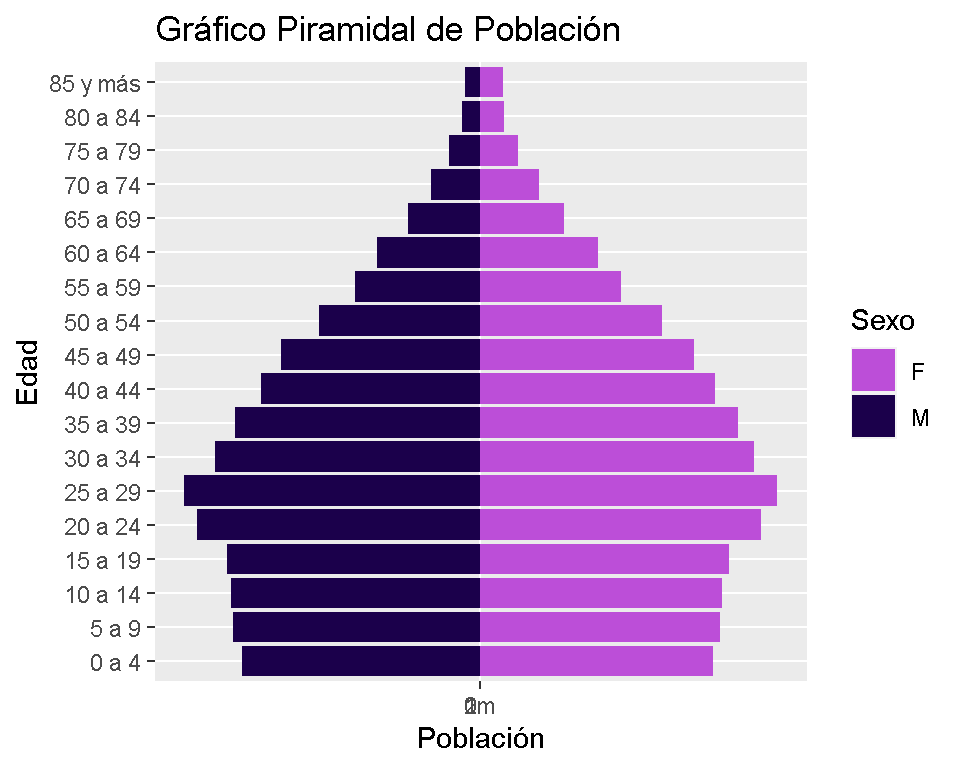

En el siguiente mapa se observa como se distribuye la población sobre la región:

[interactive chart not shown]

### Grupos de población

- Población total respecto al país: 2%. Este valor indica el peso poblacional de la zona metropolitana en relación con la población total de México.
- Población Masculina: 49%
- Población Femenina: 51%
- Relación M-F: 94.35. Este valor indica la proporción de hombres por cada mujer en la zona metropolitana.

### Socioeconómicos

La población en terminos de la poblacioón economicamente activa esta descrita por:

- Porcentaje de población de 12 años y más económicamente activa: 54%
- Porcentaje de población de 12 años y más no económicamente activa: 27% `

### Educación

La educación de la zona metropolitana esta caracterizada por los siguientes estadísticos:

- Porcentaje de población de 15 años y más sin escolaridad:2%
- Porcentaje de población de 15 años y más con al menos un grado aprobado en primaria: 73%
- Porcentaje de población de 15 años y más con educación básica completa: 17%
- Porcentaje de población de 15 años y más con secundaria o equivalente incompleta:2%
- Porcentaje de población de 18 años y más con al menos un grado aprobado en educación media superior: 42%

### Salud

La situación de la afiliación a algún servico de salud es la siguiente:

- Porcentaje de población afiliada a servicios de salud: 79%
- Población sin afiliación a servicios de salud:321356

### Indicadores de desarrollo

Finalmente se presentan tres indicadores de desarrollo; los índices son: índice de Desarrollo Humano (IDH), Índice de Marginación (IM) e Índice de Rezago Social (IRS).

IDH es un indicador elaborado por el Programa de Naciones Unidas para el Desarrollo (PNUD), este busca medir la calidad de vida, así como el progreso socioeconómico de cada entidad y municipio; El cálculo del Índice de Desarrollo Humano se realiza a partir de las tres variables: esperanza de vida, educación e ingreso per cápita.

- Muy Alto - IDH mayor de 1.
- Alto - IDH entre 0.80 a 1.
- Medio - IDH entre 0.50 y 0.80.
- Bajo - IDH entre 0 y 0.50
- Muy Bajo - IDH menores a 0.
- El promedio del IDH en 2020 para la zona metropolitana es de 0.761 según datos del PNUD.

El IM es un índice construido por el consejo Nacional de Población (CONAPO). Este índice considera 4 dimensiones estructurales para su construcción: vivienda, ingreso, educación y distribución de la población. El indice se puede ubicar en 5 estratos designados por la ténica de estratificación de Dalenius-Hodges..

Por último, el IRS es construido por el Consejo Nacional de Evaluación de la Política de Desarrollo Social, CONEVAL, este índice incorpora indicadores de educación, de acceso a servicios de salud, de servicios básicos y tiene como finalidad ordenar los municipios según sus carencias sociales. Este índice, al igual que el IM, se clasifica en cinco estratos.

## Datos económicos.

Con base en la información de los subsectores de los 21 sectores principales de la clasificación del SCIAN, extraída de los Censos Económicos del INEGI durante el periodo de 1998-2018, se ha llevado a cabo la agrupación de los datos de cada municipio que pertenece a una zona metropolitana en cinco grandes sectores: Primarios, Construcción, Manufactura, Comercio y Servicios. Esta clasificación se basa en la metodología proporcionada por el INEGI. Se utilizaron las siguientes variables:

- Unidades económicas (UE) [número de unidades]
- Activiso fijos totales (AF) [miles de pesos a precios corrientes]
- Formación bruta de capital fijo (FB) [miles de pesos a precios corrientes]
- Producción bruta total (PB) [miles de pesos a precios corrientes]
- Personal ocupado total (PO) [número de personas]
- Total de remuneraciones (RE) [miles de pesos a precios corrientes]
- Valor agregado censal bruto (VA) [miles de pesos a precios corrientes]

Posteriormente, se replica la metodología utilizada por García y Carranco (2008) para estimar los coeficientes de participación relativa (PR), de localización de la actividad económica (QL), Hirschman-Herfindahl (HH) e Inverso de Hirschman-Herfindahl (IHH).

$PR_ij$=$X_ij/X_in$

$QL_ij$=$(X_ij⁄X_j )/(X_in⁄X_n)$

$HH_ij$=$X_ij/X_in - X_j/X_n$

$IHH_ij$=$1/(X_ij/X_in - X_j/X_n)$

### Cifras brutas

#### 1999

##### UE

| Clave | Municipio | Primarios | Construcción | Manufactura | Comercio | Servicios |
| --- | --- | --- | --- | --- | --- | --- |
| 11004 | Apaseo el Alto | 0 | 0 | 208 | 867 | 153 |
| 22006 | Corregidora | 0 | 0 | 185 | 770 | 351 |
| 22008 | Huimilpan | 48 | 0 | 11 | 93 | 34 |
| 22011 | El Marqués | 0 | 0 | 83 | 290 | 44 |
| 22014 | Querétaro | 0 | 86 | 1,894 | 10,948 | 7,646 |

##### AF

| Clave | Municipio | Primarios | Construcción | Manufactura | Comercio | Servicios |
| --- | --- | --- | --- | --- | --- | --- |
| 11004 | Apaseo el Alto | 380 | 139 | 340,479 | 59,901 | 52,263 |
| 22006 | Corregidora | 0 | 17,875 | 855,495 | 75,480 | 1,044,177 |
| 22008 | Huimilpan | 205 | 0 | 2,883 | 7,324 | 31,113 |
| 22011 | El Marqués | 14,467 | 868 | 1,607,813 | 31,940 | 69,883 |
| 22014 | Querétaro | 19,690 | 498,001 | 10,430,113 | 1,942,277 | 10,733,668 |

##### FB

| Clave | Municipio | Primarios | Construcción | Manufactura | Comercio | Servicios |
| --- | --- | --- | --- | --- | --- | --- |
| 11004 | Apaseo el Alto | 28 | 0 | 32,204 | 2,789 | 3,120 |
| 22006 | Corregidora | 0 | 10,692 | 108,311 | 3,781 | 42,911 |
| 22008 | Huimilpan | 0 | 0 | 0 | 74 | 30 |
| 22011 | El Marqués | 0 | 0 | 235,488 | 17,353 | -13,375 |
| 22014 | Querétaro | 144 | 89,551 | 209,029 | 154,868 | 1,110,552 |

##### PB

| Clave | Municipio | Primarios | Construcción | Manufactura | Comercio | Servicios |
| --- | --- | --- | --- | --- | --- | --- |
| 11004 | Apaseo el Alto | 104 | 30 | 1,100,237 | 70,734 | 55,293 |
| 22006 | Corregidora | 0 | 67,744 | 1,911,123 | 308,275 | 536,737 |
| 22008 | Huimilpan | 2,373 | 0 | 3,444 | 5,139 | 8,105 |
| 22011 | El Marqués | 7,113 | 5,783 | 4,921,677 | 41,338 | 152,166 |
| 22014 | Querétaro | 36,789 | 1,526,712 | 31,610,191 | 4,801,510 | 7,292,614 |

##### PO

| Clave | Municipio | Primarios | Construcción | Manufactura | Comercio | Servicios |
| --- | --- | --- | --- | --- | --- | --- |
| 11004 | Apaseo el Alto | 3 | 1 | 1,295 | 1,558 | 913 |
| 22006 | Corregidora | 0 | 514 | 4,708 | 1,974 | 2,773 |
| 22008 | Huimilpan | 206 | 0 | 64 | 126 | 96 |
| 22011 | El Marqués | 84 | 23 | 5,729 | 657 | 573 |
| 22014 | Querétaro | 212 | 9,897 | 42,127 | 35,729 | 49,455 |

##### RE

| Clave | Municipio | Primarios | Construcción | Manufactura | Comercio | Servicios |
| --- | --- | --- | --- | --- | --- | --- |
| 11004 | Apaseo el Alto | 16 | 0 | 49,371 | 8,565 | 7,781 |
| 22006 | Corregidora | 0 | 19,061 | 243,665 | 37,728 | 104,683 |
| 22008 | Huimilpan | 1,841 | 0 | 428 | 435 | 1,173 |
| 22011 | El Marqués | 1,659 | 567 | 419,599 | 5,478 | 10,752 |
| 22014 | Querétaro | 7,521 | 173,826 | 3,066,798 | 834,695 | 1,800,416 |

##### VA

| Clave | Municipio | Primarios | Construcción | Manufactura | Comercio | Servicios |
| --- | --- | --- | --- | --- | --- | --- |
| 11004 | Apaseo el Alto | 70 | 3 | 684,680 | 49,685 | 25,031 |
| 22006 | Corregidora | 0 | 32,416 | 553,218 | 226,242 | 373,768 |
| 22008 | Huimilpan | 2,169 | 0 | 1,093 | 4,592 | 3,362 |
| 22011 | El Marqués | 3,130 | 1,522 | 1,226,731 | 34,845 | 79,271 |
| 22014 | Querétaro | 8,018 | 475,465 | 11,583,598 | 3,372,111 | 3,489,069 |

#### 2004

##### UE

| Clave | Municipio | Primarios | Construcción | Manufactura | Comercio | Servicios |
| --- | --- | --- | --- | --- | --- | --- |
| 11004 | Apaseo el Alto | 0 | 0 | 226 | 999 | 405 |
| 22006 | Corregidora | 0 | 0 | 201 | 942 | 312 |
| 22008 | Huimilpan | 30 | 0 | 8 | 93 | 40 |
| 22011 | El Marqués | 43 | 0 | 128 | 507 | 166 |
| 22014 | Querétaro | 0 | 237 | 1,808 | 12,063 | 9,866 |

##### AF

| Clave | Municipio | Primarios | Construcción | Manufactura | Comercio | Servicios |
| --- | --- | --- | --- | --- | --- | --- |
| 11004 | Apaseo el Alto | 0 | 2,694 | 56,752 | 221,835 | 131,784 |
| 22006 | Corregidora | 40 | 19,075 | 1,351,535 | 257,284 | 430,974 |
| 22008 | Huimilpan | 484 | 0 | 1,217 | 25,905 | 8,177 |
| 22011 | El Marqués | 19,543 | 127 | 2,355,304 | 767,209 | 342,728 |
| 22014 | Querétaro | 64,435 | 610,985 | 14,605,786 | 4,732,472 | 11,206,640 |

##### FB

| Clave | Municipio | Primarios | Construcción | Manufactura | Comercio | Servicios |
| --- | --- | --- | --- | --- | --- | --- |
| 11004 | Apaseo el Alto | 0 | 0 | 6,594 | 12,578 | 11,483 |
| 22006 | Corregidora | 0 | 662 | 59,427 | 17,784 | 34,927 |
| 22008 | Huimilpan | 28 | 0 | 50 | 809 | 931 |
| 22011 | El Marqués | 0 | 127 | 247,249 | 56,141 | 76,146 |
| 22014 | Querétaro | 11,286 | 73,399 | 1,420,826 | 421,979 | 630,554 |

##### PB

| Clave | Municipio | Primarios | Construcción | Manufactura | Comercio | Servicios |
| --- | --- | --- | --- | --- | --- | --- |
| 11004 | Apaseo el Alto | 0 | 3,216 | 80,920 | 245,210 | 113,828 |
| 22006 | Corregidora | 16 | 39,636 | 6,386,258 | 542,541 | 1,362,002 |
| 22008 | Huimilpan | 887 | 0 | 4,151 | 14,755 | 22,847 |
| 22011 | El Marqués | 46,831 | 4,422 | 9,401,342 | 1,448,900 | 475,659 |
| 22014 | Querétaro | 62,545 | 3,410,277 | 38,995,700 | 10,747,090 | 16,864,677 |

##### PO

| Clave | Municipio | Primarios | Construcción | Manufactura | Comercio | Servicios |
| --- | --- | --- | --- | --- | --- | --- |
| 11004 | Apaseo el Alto | 0 | 12 | 1,006 | 2,372 | 1,301 |
| 22006 | Corregidora | 9 | 354 | 6,779 | 3,072 | 3,575 |
| 22008 | Huimilpan | 50 | 0 | 44 | 189 | 112 |
| 22011 | El Marqués | 207 | 24 | 10,107 | 2,072 | 2,076 |
| 22014 | Querétaro | 182 | 10,856 | 41,224 | 52,162 | 66,634 |

##### RE

| Clave | Municipio | Primarios | Construcción | Manufactura | Comercio | Servicios |
| --- | --- | --- | --- | --- | --- | --- |
| 11004 | Apaseo el Alto | 0 | 155 | 19,164 | 49,254 | 16,943 |
| 22006 | Corregidora | 0 | 8,080 | 562,001 | 65,093 | 227,279 |
| 22008 | Huimilpan | 0 | 0 | 1,249 | 2,447 | 4,820 |
| 22011 | El Marqués | 8,556 | 169 | 757,163 | 52,158 | 80,355 |
| 22014 | Querétaro | 8,341 | 457,594 | 4,126,272 | 1,779,928 | 3,719,075 |

##### VA

| Clave | Municipio | Primarios | Construcción | Manufactura | Comercio | Servicios |
| --- | --- | --- | --- | --- | --- | --- |
| 11004 | Apaseo el Alto | 0 | 526 | 33,444 | 168,058 | 63,559 |
| 22006 | Corregidora | 14 | 8,159 | 2,739,177 | 410,625 | 824,694 |
| 22008 | Huimilpan | 683 | 0 | 2,293 | 10,152 | 10,779 |
| 22011 | El Marqués | 31,585 | 183 | 2,822,082 | 476,019 | 269,378 |
| 22014 | Querétaro | 37,608 | 1,111,369 | 12,527,293 | 7,531,696 | 8,944,440 |

#### 2009

##### UE

| Clave | Municipio | Primarios | Construcción | Manufactura | Comercio | Servicios |
| --- | --- | --- | --- | --- | --- | --- |
| 11004 | Apaseo el Alto | 0 | 0 | 248 | 1,123 | 573 |
| 22006 | Corregidora | 0 | 12 | 295 | 1,385 | 1,070 |
| 22008 | Huimilpan | 66 | 0 | 0 | 95 | 43 |
| 22011 | El Marqués | 41 | 0 | 274 | 817 | 190 |
| 22014 | Querétaro | 0 | 298 | 2,584 | 15,280 | 13,326 |

##### AF

| Clave | Municipio | Primarios | Construcción | Manufactura | Comercio | Servicios |
| --- | --- | --- | --- | --- | --- | --- |
| 11004 | Apaseo el Alto | 0 | 5,563 | 69,030 | 224,668 | 306,083 |
| 22006 | Corregidora | 91 | 63,175 | 2,185,845 | 612,881 | 471,788 |
| 22008 | Huimilpan | 1,388 | 0 | 2,063 | 23,255 | 17,288 |
| 22011 | El Marqués | 17,696 | 13,575 | 7,661,399 | 616,800 | 5,580,351 |
| 22014 | Querétaro | 7,486 | 1,555,488 | 25,956,082 | 7,351,699 | 19,068,095 |

##### FB

| Clave | Municipio | Primarios | Construcción | Manufactura | Comercio | Servicios |
| --- | --- | --- | --- | --- | --- | --- |
| 11004 | Apaseo el Alto | 0 | -12 | 1,488 | 2,444 | 19,349 |
| 22006 | Corregidora | 1 | 7,601 | 719,404 | 61,772 | 30,487 |
| 22008 | Huimilpan | 202 | 0 | 9 | 317 | 721 |
| 22011 | El Marqués | 93 | 116 | 414,035 | 85,083 | 14,450 |
| 22014 | Querétaro | 502 | 200,397 | 1,504,873 | 486,207 | 1,516,305 |

##### PB

| Clave | Municipio | Primarios | Construcción | Manufactura | Comercio | Servicios |
| --- | --- | --- | --- | --- | --- | --- |
| 11004 | Apaseo el Alto | 0 | 4,254 | 75,801 | 160,109 | 349,082 |
| 22006 | Corregidora | 1,260 | 384,599 | 6,994,488 | 1,050,681 | 2,119,339 |
| 22008 | Huimilpan | 4,695 | 0 | 3,400 | 10,738 | 34,400 |
| 22011 | El Marqués | 25,750 | 87,540 | 30,310,360 | 1,507,226 | 1,676,065 |
| 22014 | Querétaro | 18,002 | 6,766,164 | 77,344,305 | 15,410,094 | 31,240,759 |

##### PO

| Clave | Municipio | Primarios | Construcción | Manufactura | Comercio | Servicios |
| --- | --- | --- | --- | --- | --- | --- |
| 11004 | Apaseo el Alto | 0 | 18 | 872 | 2,794 | 1,937 |
| 22006 | Corregidora | 4 | 1,299 | 6,549 | 5,620 | 6,669 |
| 22008 | Huimilpan | 145 | 0 | 31 | 277 | 184 |
| 22011 | El Marqués | 170 | 90 | 20,966 | 3,516 | 3,763 |
| 22014 | Querétaro | 77 | 13,399 | 55,795 | 63,111 | 108,055 |

##### RE

| Clave | Municipio | Primarios | Construcción | Manufactura | Comercio | Servicios |
| --- | --- | --- | --- | --- | --- | --- |
| 11004 | Apaseo el Alto | 0 | 605 | 11,546 | 21,237 | 31,039 |
| 22006 | Corregidora | 293 | 73,678 | 657,114 | 197,164 | 296,991 |
| 22008 | Huimilpan | 723 | 0 | 891 | 2,390 | 6,237 |
| 22011 | El Marqués | 4,066 | 6,169 | 1,771,199 | 94,900 | 296,218 |
| 22014 | Querétaro | 4,957 | 946,785 | 5,334,578 | 2,128,828 | 7,351,941 |

##### VA

| Clave | Municipio | Primarios | Construcción | Manufactura | Comercio | Servicios |
| --- | --- | --- | --- | --- | --- | --- |
| 11004 | Apaseo el Alto | 0 | 1,901 | 30,153 | 101,856 | 200,321 |
| 22006 | Corregidora | 939 | 117,687 | 2,002,493 | 624,577 | 1,434,448 |
| 22008 | Huimilpan | 3,353 | 0 | 1,185 | 7,811 | 21,410 |
| 22011 | El Marqués | 12,740 | 8,447 | 8,673,098 | 970,333 | 588,882 |
| 22014 | Querétaro | 8,894 | 2,239,537 | 25,222,636 | 9,382,447 | 15,354,924 |

#### 2014

##### UE

| Clave | Municipio | Primarios | Construcción | Manufactura | Comercio | Servicios |
| --- | --- | --- | --- | --- | --- | --- |
| 11004 | Apaseo el Alto | 0 | 0 | 337 | 1,328 | 839 |
| 22006 | Corregidora | 0 | 34 | 482 | 1,983 | 1,955 |
| 22008 | Huimilpan | 63 | 0 | 12 | 197 | 93 |
| 22011 | El Marqués | 60 | 0 | 370 | 1,202 | 673 |
| 22014 | Querétaro | 4 | 294 | 2,991 | 17,695 | 17,261 |

##### AF

| Clave | Municipio | Primarios | Construcción | Manufactura | Comercio | Servicios |
| --- | --- | --- | --- | --- | --- | --- |
| 11004 | Apaseo el Alto | 0 | 0 | 92,857 | 224,792 | 190,827 |
| 22006 | Corregidora | 0 | 89,961 | 3,671,301 | 985,852 | 1,356,728 |
| 22008 | Huimilpan | 39,377 | 0 | 3,190 | 38,262 | 13,103 |
| 22011 | El Marqués | 49,793 | 0 | 12,026,597 | 807,406 | 1,155,057 |
| 22014 | Querétaro | 14,315 | 1,710,155 | 34,097,106 | 10,914,634 | 21,033,426 |

##### FB

| Clave | Municipio | Primarios | Construcción | Manufactura | Comercio | Servicios |
| --- | --- | --- | --- | --- | --- | --- |
| 11004 | Apaseo el Alto | 0 | 0 | 4,358 | 3,298 | 4,225 |
| 22006 | Corregidora | 0 | 6,566 | 326,974 | -28,028 | 31,653 |
| 22008 | Huimilpan | 996 | 0 | 40 | 537 | 64 |
| 22011 | El Marqués | 1,780 | 0 | 1,159,595 | 66,783 | 30,983 |
| 22014 | Querétaro | 0 | 148,500 | 2,624,488 | -89,275 | 1,201,021 |

##### PB

| Clave | Municipio | Primarios | Construcción | Manufactura | Comercio | Servicios |
| --- | --- | --- | --- | --- | --- | --- |
| 11004 | Apaseo el Alto | 0 | 0 | 161,142 | 414,475 | 161,067 |
| 22006 | Corregidora | 0 | 394,709 | 14,602,932 | 2,165,256 | 1,516,001 |
| 22008 | Huimilpan | 64,146 | 0 | 3,908 | 18,548 | 18,268 |
| 22011 | El Marqués | 27,402 | 0 | 52,742,856 | 2,171,014 | 2,374,796 |
| 22014 | Querétaro | 35,620 | 5,510,571 | 112,008,136 | 23,023,276 | 44,739,632 |

##### PO

| Clave | Municipio | Primarios | Construcción | Manufactura | Comercio | Servicios |
| --- | --- | --- | --- | --- | --- | --- |
| 11004 | Apaseo el Alto | 0 | 0 | 948 | 2,807 | 1,687 |
| 22006 | Corregidora | 0 | 840 | 9,848 | 7,151 | 8,398 |
| 22008 | Huimilpan | 110 | 0 | 33 | 341 | 191 |
| 22011 | El Marqués | 152 | 0 | 33,535 | 5,524 | 5,734 |
| 22014 | Querétaro | 47 | 11,296 | 78,912 | 71,168 | 115,548 |

##### RE

| Clave | Municipio | Primarios | Construcción | Manufactura | Comercio | Servicios |
| --- | --- | --- | --- | --- | --- | --- |
| 11004 | Apaseo el Alto | 0 | 0 | 20,280 | 64,382 | 17,693 |
| 22006 | Corregidora | 0 | 43,184 | 951,633 | 311,844 | 320,813 |
| 22008 | Huimilpan | 1,240 | 0 | 241 | 1,196 | 1,237 |
| 22011 | El Marqués | 7,781 | 0 | 3,646,348 | 279,556 | 364,791 |
| 22014 | Querétaro | 2,372 | 780,259 | 6,877,848 | 3,397,371 | 8,270,677 |

##### VA

| Clave | Municipio | Primarios | Construcción | Manufactura | Comercio | Servicios |
| --- | --- | --- | --- | --- | --- | --- |
| 11004 | Apaseo el Alto | 0 | 0 | 62,559 | 248,156 | 69,552 |
| 22006 | Corregidora | 0 | 111,354 | 4,055,310 | 1,461,196 | 651,360 |
| 22008 | Huimilpan | 22,697 | 0 | 861 | 13,469 | 5,661 |
| 22011 | El Marqués | 16,783 | 0 | 9,289,524 | 1,160,649 | 998,367 |
| 22014 | Querétaro | 32,756 | 1,926,796 | 24,797,432 | 15,066,798 | 19,167,035 |

#### 2019

##### UE

| Clave | Municipio | Primarios | Construcción | Manufactura | Comercio | Servicios |
| --- | --- | --- | --- | --- | --- | --- |
| 11004 | Apaseo el Alto | 0 | 3 | 404 | 1,482 | 989 |
| 22006 | Corregidora | 1 | 36 | 483 | 2,362 | 2,630 |
| 22008 | Huimilpan | 67 | 1 | 41 | 262 | 135 |
| 22011 | El Marqués | 51 | 14 | 572 | 1,886 | 1,319 |
| 22014 | Querétaro | 11 | 347 | 3,363 | 19,607 | 20,825 |

##### AF

| Clave | Municipio | Primarios | Construcción | Manufactura | Comercio | Servicios |
| --- | --- | --- | --- | --- | --- | --- |
| 11004 | Apaseo el Alto | 0 | 0 | 1,803,691 | 794,185 | 259,453 |
| 22006 | Corregidora | 0 | 160,557 | 4,140,394 | 1,625,795 | 1,812,386 |
| 22008 | Huimilpan | 81,049 | 0 | 259,301 | 69,408 | 22,915 |
| 22011 | El Marqués | 472,760 | 159,845 | 29,830,803 | 2,521,999 | 3,629,039 |
| 22014 | Querétaro | 16,045 | 2,951,098 | 61,748,537 | 20,340,227 | 31,644,845 |

##### FB

| Clave | Municipio | Primarios | Construcción | Manufactura | Comercio | Servicios |
| --- | --- | --- | --- | --- | --- | --- |
| 11004 | Apaseo el Alto | 0 | 0 | 107,733 | 59,066 | 33,921 |
| 22006 | Corregidora | 0 | 1,669 | 213,889 | 189,764 | -28,292 |
| 22008 | Huimilpan | 1,140 | 0 | 13,123 | 2,140 | 139 |
| 22011 | El Marqués | 35 | 49,372 | 4,314,227 | 155,526 | 87,974 |
| 22014 | Querétaro | 1,094 | 125,315 | 5,994,085 | 1,432,754 | 1,305,241 |

##### PB

| Clave | Municipio | Primarios | Construcción | Manufactura | Comercio | Servicios |
| --- | --- | --- | --- | --- | --- | --- |
| 11004 | Apaseo el Alto | 0 | 0 | 5,448,196 | 657,137 | 332,668 |
| 22006 | Corregidora | 0 | 1,149,413 | 20,035,723 | 4,024,314 | 3,685,692 |
| 22008 | Huimilpan | 137,286 | 0 | 523,450 | 92,412 | 45,540 |
| 22011 | El Marqués | 233,576 | 775,203 | 124,407,186 | 7,669,514 | 7,366,170 |
| 22014 | Querétaro | 31,441 | 12,723,379 | 226,004,983 | 48,528,742 | 75,933,052 |

##### PO

| Clave | Municipio | Primarios | Construcción | Manufactura | Comercio | Servicios |
| --- | --- | --- | --- | --- | --- | --- |
| 11004 | Apaseo el Alto | 0 | 0 | 3,833 | 3,216 | 2,471 |
| 22006 | Corregidora | 0 | 1,633 | 9,223 | 8,708 | 13,695 |
| 22008 | Huimilpan | 120 | 0 | 693 | 632 | 255 |
| 22011 | El Marqués | 338 | 939 | 60,313 | 10,288 | 17,994 |
| 22014 | Querétaro | 70 | 17,608 | 103,369 | 87,436 | 202,356 |

##### RE

| Clave | Municipio | Primarios | Construcción | Manufactura | Comercio | Servicios |
| --- | --- | --- | --- | --- | --- | --- |
| 11004 | Apaseo el Alto | 0 | 0 | 130,070 | 80,563 | 98,486 |
| 22006 | Corregidora | 0 | 127,760 | 866,426 | 470,846 | 716,372 |
| 22008 | Huimilpan | 1,458 | 0 | 72,986 | 19,417 | 3,603 |
| 22011 | El Marqués | 27,320 | 69,597 | 7,624,990 | 629,179 | 1,757,850 |
| 22014 | Querétaro | 9,127 | 1,287,503 | 12,665,305 | 4,095,612 | 14,566,348 |

##### VA

| Clave | Municipio | Primarios | Construcción | Manufactura | Comercio | Servicios |
| --- | --- | --- | --- | --- | --- | --- |
| 11004 | Apaseo el Alto | 0 | 0 | 1,894,620 | 456,757 | 79,062 |
| 22006 | Corregidora | 0 | 317,045 | 5,047,674 | 2,787,899 | 1,943,444 |
| 22008 | Huimilpan | 36,629 | 0 | 146,089 | 47,132 | 20,236 |
| 22011 | El Marqués | 85,976 | 210,890 | 37,987,310 | 4,431,870 | 4,164,170 |
| 22014 | Querétaro | 15,485 | 4,540,375 | 60,661,916 | 31,784,113 | 41,209,758 |

### Coeficientes de localización (QL)

#### 1999

##### UE

| Clave | Municipio | Primarios | Construcción | Manufactura | Comercio | Servicios |
| --- | --- | --- | --- | --- | --- | --- |
| 11004 | Apaseo el Alto | 0.0000 | 0.0000 | 1.5266 | 1.3381 | 0.3531 |
| 22006 | Corregidora | 0.0000 | 0.0000 | 1.2767 | 1.1174 | 0.7617 |
| 22008 | Huimilpan | 97.1655 | 0.0000 | 0.5330 | 0.9476 | 0.5181 |
| 22011 | El Marqués | 0.0000 | 0.0000 | 1.7939 | 1.3181 | 0.2991 |
| 22014 | Querétaro | 0.0000 | 0.7029 | 0.8297 | 1.0085 | 1.0533 |

##### AF

| Clave | Municipio | Primarios | Construcción | Manufactura | Comercio | Servicios |
| --- | --- | --- | --- | --- | --- | --- |
| 11004 | Apaseo el Alto | 0.0345 | 0.0201 | 2.2082 | 1.7404 | 0.2119 |
| 22006 | Corregidora | 0.0000 | 0.5891 | 1.2616 | 0.4986 | 0.9627 |
| 22008 | Huimilpan | 0.2028 | 0.0000 | 0.2041 | 2.3223 | 1.3767 |
| 22011 | El Marqués | 0.3446 | 0.0330 | 2.7394 | 0.2438 | 0.0744 |
| 22014 | Querétaro | 0.0342 | 1.3845 | 1.2976 | 1.0825 | 0.8349 |

##### FB

[output not shown]

##### PB

| Clave | Municipio | Primarios | Construcción | Manufactura | Comercio | Servicios |
| --- | --- | --- | --- | --- | --- | --- |
| 11004 | Apaseo el Alto | 0.0085 | 0.0007 | 1.8130 | 0.4128 | 0.1412 |
| 22006 | Corregidora | 0.0000 | 0.6648 | 1.3677 | 0.7812 | 0.5951 |
| 22008 | Huimilpan | 12.4756 | 0.0000 | 0.3652 | 1.9294 | 1.3314 |
| 22011 | El Marqués | 0.1390 | 0.0313 | 1.9396 | 0.0577 | 0.0929 |
| 22014 | Querétaro | 0.0814 | 0.9347 | 1.4112 | 0.7591 | 0.5044 |

##### PO

| Clave | Municipio | Primarios | Construcción | Manufactura | Comercio | Servicios |
| --- | --- | --- | --- | --- | --- | --- |
| 11004 | Apaseo el Alto | 0.0897 | 0.0049 | 1.1128 | 1.5927 | 0.6558 |
| 22006 | Corregidora | 0.0000 | 0.9602 | 1.5299 | 0.7632 | 0.7533 |
| 22008 | Huimilpan | 47.2022 | 0.0000 | 0.4214 | 0.9870 | 0.5284 |
| 22011 | El Marqués | 1.3402 | 0.0606 | 2.6265 | 0.3583 | 0.2196 |
| 22014 | Querétaro | 0.1739 | 1.3412 | 0.9931 | 1.0020 | 0.9746 |

##### RE

| Clave | Municipio | Primarios | Construcción | Manufactura | Comercio | Servicios |
| --- | --- | --- | --- | --- | --- | --- |
| 11004 | Apaseo el Alto | 0.0215 | 0.0000 | 2.0314 | 0.9176 | 0.2623 |
| 22006 | Corregidora | 0.0000 | 1.8308 | 1.6266 | 0.6558 | 0.5727 |
| 22008 | Huimilpan | 41.8729 | 0.0000 | 0.2986 | 0.7901 | 0.6705 |
| 22011 | El Marqués | 0.3340 | 0.0504 | 2.5906 | 0.0881 | 0.0544 |
| 22014 | Querétaro | 0.1127 | 1.1497 | 1.4098 | 0.9991 | 0.6782 |

##### VA

| Clave | Municipio | Primarios | Construcción | Manufactura | Comercio | Servicios |
| --- | --- | --- | --- | --- | --- | --- |
| 11004 | Apaseo el Alto | 0.0078 | 0.0002 | 2.4468 | 0.2937 | 0.0879 |
| 22006 | Corregidora | 0.0000 | 1.2298 | 1.2664 | 0.8567 | 0.8411 |
| 22008 | Huimilpan | 16.4477 | 0.0000 | 0.2645 | 1.8381 | 0.7997 |
| 22011 | El Marqués | 0.1979 | 0.0509 | 2.4745 | 0.1163 | 0.1572 |
| 22014 | Querétaro | 0.0360 | 1.1299 | 1.6609 | 0.7998 | 0.4918 |

#### 2004

##### UE

| Clave | Municipio | Primarios | Construcción | Manufactura | Comercio | Servicios |
| --- | --- | --- | --- | --- | --- | --- |
| 11004 | Apaseo el Alto | 0.0000 | 0.0000 | 1.4185 | 1.1351 | 0.6988 |
| 22006 | Corregidora | 0.0000 | 0.0000 | 1.4133 | 1.1991 | 0.6031 |
| 22008 | Huimilpan | 97.4238 | 0.0000 | 0.4786 | 1.0073 | 0.6579 |
| 22011 | El Marqués | 28.2922 | 0.0000 | 1.5516 | 1.1126 | 0.5531 |
| 22014 | Querétaro | 0.0000 | 1.9977 | 0.7715 | 0.9319 | 1.1574 |

##### AF

| Clave | Municipio | Primarios | Construcción | Manufactura | Comercio | Servicios |
| --- | --- | --- | --- | --- | --- | --- |
| 11004 | Apaseo el Alto | 0.0000 | 0.5936 | 0.3750 | 5.9714 | 0.6182 |
| 22006 | Corregidora | 0.0012 | 0.8433 | 1.7918 | 1.3894 | 0.4056 |
| 22008 | Huimilpan | 0.8133 | 0.0000 | 0.0928 | 8.0496 | 0.4428 |
| 22011 | El Marqués | 0.3372 | 0.0033 | 1.8448 | 2.4479 | 0.1906 |
| 22014 | Querétaro | 0.1241 | 1.7812 | 1.2770 | 1.6855 | 0.6955 |

##### FB

[output not shown]

##### PB

| Clave | Municipio | Primarios | Construcción | Manufactura | Comercio | Servicios |
| --- | --- | --- | --- | --- | --- | --- |
| 11004 | Apaseo el Alto | 0.0000 | 0.2293 | 0.3953 | 4.0282 | 0.7157 |
| 22006 | Corregidora | 0.0002 | 0.1503 | 1.6597 | 0.4741 | 0.4556 |
| 22008 | Huimilpan | 2.0357 | 0.0000 | 0.2108 | 2.5193 | 1.4930 |
| 22011 | El Marqués | 0.4028 | 0.0123 | 1.7890 | 0.9272 | 0.1165 |
| 22014 | Querétaro | 0.0873 | 1.5374 | 1.2047 | 1.1165 | 0.6705 |

##### PO

| Clave | Municipio | Primarios | Construcción | Manufactura | Comercio | Servicios |
| --- | --- | --- | --- | --- | --- | --- |
| 11004 | Apaseo el Alto | 0.0000 | 0.0553 | 0.8139 | 1.7295 | 0.7118 |
| 22006 | Corregidora | 0.0790 | 0.5550 | 1.8659 | 0.7620 | 0.6654 |
| 22008 | Huimilpan | 15.3142 | 0.0000 | 0.4228 | 1.6366 | 0.7277 |
| 22011 | El Marqués | 1.7288 | 0.0358 | 2.6480 | 0.4892 | 0.3678 |
| 22014 | Querétaro | 0.1287 | 1.3720 | 0.9147 | 1.0430 | 0.9998 |

##### RE

| Clave | Municipio | Primarios | Construcción | Manufactura | Comercio | Servicios |
| --- | --- | --- | --- | --- | --- | --- |
| 11004 | Apaseo el Alto | 0.0000 | 0.0694 | 0.6390 | 3.6841 | 0.4332 |
| 22006 | Corregidora | 0.0000 | 0.3588 | 1.8580 | 0.4828 | 0.5762 |
| 22008 | Huimilpan | 0.0000 | 0.0000 | 0.4182 | 1.8379 | 1.2376 |
| 22011 | El Marqués | 1.0004 | 0.0072 | 2.4031 | 0.3714 | 0.1956 |
| 22014 | Querétaro | 0.0868 | 1.7365 | 1.1659 | 1.1282 | 0.8059 |

##### VA

| Clave | Municipio | Primarios | Construcción | Manufactura | Comercio | Servicios |
| --- | --- | --- | --- | --- | --- | --- |
| 11004 | Apaseo el Alto | 0.0000 | 0.0886 | 0.3874 | 3.2120 | 0.5445 |
| 22006 | Corregidora | 0.0002 | 0.0917 | 2.1160 | 0.5234 | 0.4711 |
| 22008 | Huimilpan | 1.7732 | 0.0000 | 0.2951 | 2.1555 | 1.0259 |
| 22011 | El Marqués | 0.5447 | 0.0023 | 2.4123 | 0.6713 | 0.1703 |
| 22014 | Querétaro | 0.0774 | 1.6494 | 1.2782 | 1.2679 | 0.6749 |

#### 2009

##### UE

| Clave | Municipio | Primarios | Construcción | Manufactura | Comercio | Servicios |
| --- | --- | --- | --- | --- | --- | --- |
| 11004 | Apaseo el Alto | 0.0000 | 0.0000 | 1.2386 | 1.1361 | 0.7734 |
| 22006 | Corregidora | 0.0000 | 0.7300 | 1.0370 | 0.9862 | 1.0165 |
| 22008 | Huimilpan | 221.1598 | 0.0000 | 0.0000 | 0.9159 | 0.5531 |
| 22011 | El Marqués | 21.2004 | 0.0000 | 2.0123 | 1.2154 | 0.3771 |
| 22014 | Querétaro | 0.0000 | 1.5902 | 0.7967 | 0.9544 | 1.1104 |

##### AF

| Clave | Municipio | Primarios | Construcción | Manufactura | Comercio | Servicios |
| --- | --- | --- | --- | --- | --- | --- |
| 11004 | Apaseo el Alto | 0.0000 | 0.5787 | 0.4264 | 3.9468 | 0.8376 |
| 22006 | Corregidora | 0.0014 | 1.1934 | 2.4515 | 1.9550 | 0.2344 |
| 22008 | Huimilpan | 1.6645 | 0.0000 | 0.1753 | 5.6212 | 0.6510 |
| 22011 | El Marqués | 0.0672 | 0.0615 | 2.0623 | 0.4722 | 0.6655 |
| 22014 | Querétaro | 0.0073 | 1.8161 | 1.7992 | 1.4494 | 0.5856 |

##### FB

[output not shown]

##### PB

| Clave | Municipio | Primarios | Construcción | Manufactura | Comercio | Servicios |
| --- | --- | --- | --- | --- | --- | --- |
| 11004 | Apaseo el Alto | 0.0000 | 0.1708 | 0.2651 | 2.5971 | 1.6941 |
| 22006 | Corregidora | 0.0066 | 0.8623 | 1.3661 | 0.9519 | 0.5744 |
| 22008 | Huimilpan | 4.8700 | 0.0000 | 0.1316 | 1.9280 | 1.8480 |
| 22011 | El Marqués | 0.0423 | 0.0616 | 1.8585 | 0.4287 | 0.1426 |
| 22014 | Querétaro | 0.0076 | 1.2238 | 1.2186 | 1.1263 | 0.6831 |

##### PO

| Clave | Municipio | Primarios | Construcción | Manufactura | Comercio | Servicios |
| --- | --- | --- | --- | --- | --- | --- |
| 11004 | Apaseo el Alto | 0.0000 | 0.0806 | 0.6525 | 1.7482 | 0.7995 |
| 22006 | Corregidora | 0.0278 | 1.6228 | 1.3676 | 0.9814 | 0.7682 |
| 22008 | Huimilpan | 31.8849 | 0.0000 | 0.2047 | 1.5294 | 0.6701 |
| 22011 | El Marqués | 0.8354 | 0.0794 | 3.0936 | 0.4338 | 0.3063 |
| 22014 | Querétaro | 0.0449 | 1.4022 | 0.9760 | 0.9232 | 1.0426 |

##### RE

| Clave | Municipio | Primarios | Construcción | Manufactura | Comercio | Servicios |
| --- | --- | --- | --- | --- | --- | --- |
| 11004 | Apaseo el Alto | 0.0000 | 0.2508 | 0.5436 | 2.5859 | 0.9795 |
| 22006 | Corregidora | 0.0176 | 1.6058 | 1.6267 | 1.2624 | 0.4928 |
| 22008 | Huimilpan | 5.2103 | 0.0000 | 0.2639 | 1.8308 | 1.2383 |
| 22011 | El Marqués | 0.1381 | 0.0758 | 2.4728 | 0.3427 | 0.2772 |
| 22014 | Querétaro | 0.0232 | 1.6035 | 1.0262 | 1.0592 | 0.9480 |

##### VA

| Clave | Municipio | Primarios | Construcción | Manufactura | Comercio | Servicios |
| --- | --- | --- | --- | --- | --- | --- |
| 11004 | Apaseo el Alto | 0.0000 | 0.1921 | 0.2545 | 2.1128 | 1.3518 |
| 22006 | Corregidora | 0.0079 | 0.9511 | 1.3516 | 1.0359 | 0.7740 |
| 22008 | Huimilpan | 3.5005 | 0.0000 | 0.0990 | 1.6041 | 1.4304 |
| 22011 | El Marqués | 0.0438 | 0.0278 | 2.3866 | 0.6561 | 0.1295 |
| 22014 | Querétaro | 0.0060 | 1.4491 | 1.3631 | 1.2459 | 0.6634 |

#### 2014

##### UE

| Clave | Municipio | Primarios | Construcción | Manufactura | Comercio | Servicios |
| --- | --- | --- | --- | --- | --- | --- |
| 11004 | Apaseo el Alto | 0.0000 | 0.0000 | 1.3704 | 1.0865 | 0.8233 |
| 22006 | Corregidora | 0.0000 | 1.5296 | 1.1019 | 0.9121 | 1.0785 |
| 22008 | Huimilpan | 102.1488 | 0.0000 | 0.3348 | 1.1057 | 0.6260 |
| 22011 | El Marqués | 15.4051 | 0.0000 | 1.6345 | 1.0683 | 0.7174 |
| 22014 | Querétaro | 0.0619 | 1.5403 | 0.7963 | 0.9479 | 1.1089 |

##### AF

| Clave | Municipio | Primarios | Construcción | Manufactura | Comercio | Servicios |
| --- | --- | --- | --- | --- | --- | --- |
| 11004 | Apaseo el Alto | 0.0000 | 0.0000 | 0.6679 | 4.0218 | 0.6356 |
| 22006 | Corregidora | 0.0000 | 1.1268 | 2.1998 | 1.4693 | 0.3764 |
| 22008 | Huimilpan | 31.9879 | 0.0000 | 0.1242 | 3.7056 | 0.2362 |
| 22011 | El Marqués | 0.2706 | 0.0000 | 3.1331 | 0.5232 | 0.1393 |
| 22014 | Querétaro | 0.0161 | 1.9292 | 1.8401 | 1.4651 | 0.5256 |

##### FB

[output not shown]

##### PB

| Clave | Municipio | Primarios | Construcción | Manufactura | Comercio | Servicios |
| --- | --- | --- | --- | --- | --- | --- |
| 11004 | Apaseo el Alto | 0.0000 | 0.0000 | 0.4476 | 4.7185 | 0.6139 |
| 22006 | Corregidora | 0.0000 | 0.6981 | 1.5998 | 0.9722 | 0.2279 |
| 22008 | Huimilpan | 108.4809 | 0.0000 | 0.0763 | 1.4833 | 0.4891 |
| 22011 | El Marqués | 0.0848 | 0.0000 | 1.8830 | 0.3177 | 0.1163 |
| 22014 | Querétaro | 0.0341 | 0.9824 | 1.2368 | 1.0419 | 0.6778 |

##### PO

| Clave | Municipio | Primarios | Construcción | Manufactura | Comercio | Servicios |
| --- | --- | --- | --- | --- | --- | --- |
| 11004 | Apaseo el Alto | 0.0000 | 0.0000 | 0.7210 | 1.8086 | 0.7058 |
| 22006 | Corregidora | 0.0000 | 1.0711 | 1.5535 | 0.9557 | 0.7287 |
| 22008 | Huimilpan | 40.0464 | 0.0000 | 0.2023 | 1.7714 | 0.6442 |
| 22011 | El Marqués | 0.8311 | 0.0000 | 3.0881 | 0.4310 | 0.2905 |
| 22014 | Querétaro | 0.0417 | 1.3644 | 1.1792 | 0.9010 | 0.9498 |

##### RE

| Clave | Municipio | Primarios | Construcción | Manufactura | Comercio | Servicios |
| --- | --- | --- | --- | --- | --- | --- |
| 11004 | Apaseo el Alto | 0.0000 | 0.0000 | 0.5804 | 4.5764 | 0.3590 |
| 22006 | Corregidora | 0.0000 | 1.1323 | 1.7128 | 1.3941 | 0.4094 |
| 22008 | Huimilpan | 19.4623 | 0.0000 | 0.1804 | 2.2232 | 0.6564 |
| 22011 | El Marqués | 0.1112 | 0.0000 | 2.4848 | 0.4732 | 0.1763 |
| 22014 | Querétaro | 0.0075 | 1.7226 | 1.0423 | 1.2788 | 0.8888 |

##### VA

| Clave | Municipio | Primarios | Construcción | Manufactura | Comercio | Servicios |
| --- | --- | --- | --- | --- | --- | --- |
| 11004 | Apaseo el Alto | 0.0000 | 0.0000 | 0.4892 | 3.6982 | 0.3998 |
| 22006 | Corregidora | 0.0000 | 0.8051 | 1.9205 | 1.3187 | 0.2267 |
| 22008 | Huimilpan | 69.2298 | 0.0000 | 0.0600 | 1.7880 | 0.2898 |
| 22011 | El Marqués | 0.1906 | 0.0000 | 2.4093 | 0.5737 | 0.1903 |
| 22014 | Querétaro | 0.0699 | 1.4342 | 1.2090 | 1.3999 | 0.6868 |

#### 2019

##### UE

| Clave | Municipio | Primarios | Construcción | Manufactura | Comercio | Servicios |
| --- | --- | --- | --- | --- | --- | --- |
| 11004 | Apaseo el Alto | 0.0000 | 0.2009 | 1.4201 | 1.0979 | 0.8094 |
| 22006 | Corregidora | 0.0764 | 1.2591 | 0.8865 | 0.9136 | 1.1239 |
| 22008 | Huimilpan | 55.7303 | 0.3810 | 0.8197 | 1.1040 | 0.6284 |
| 22011 | El Marqués | 5.5870 | 0.7025 | 1.5061 | 1.0466 | 0.8086 |
| 22014 | Querétaro | 0.1049 | 1.5150 | 0.7705 | 0.9468 | 1.1109 |

##### AF

| Clave | Municipio | Primarios | Construcción | Manufactura | Comercio | Servicios |
| --- | --- | --- | --- | --- | --- | --- |
| 11004 | Apaseo el Alto | 0.0000 | 0.0000 | 2.2283 | 1.4199 | 0.1841 |
| 22006 | Corregidora | 0.0000 | 1.6983 | 1.8885 | 1.0731 | 0.4748 |
| 22008 | Huimilpan | 12.1046 | 0.0000 | 2.1155 | 0.8195 | 0.1074 |
| 22011 | El Marqués | 0.8344 | 0.3574 | 2.8760 | 0.3519 | 0.2009 |
| 22014 | Querétaro | 0.0089 | 2.0701 | 1.8678 | 0.8904 | 0.5497 |

##### FB

[output not shown]

##### PB

| Clave | Municipio | Primarios | Construcción | Manufactura | Comercio | Servicios |
| --- | --- | --- | --- | --- | --- | --- |
| 11004 | Apaseo el Alto | 0.0000 | 0.0000 | 1.6952 | 0.7303 | 0.1574 |
| 22006 | Corregidora | 0.0000 | 1.3976 | 1.3890 | 0.9965 | 0.3886 |
| 22008 | Huimilpan | 39.2869 | 0.0000 | 1.3129 | 0.8279 | 0.1737 |
| 22011 | El Marqués | 0.3801 | 0.1939 | 1.7744 | 0.3907 | 0.1598 |
| 22014 | Querétaro | 0.0198 | 1.2307 | 1.2464 | 0.9560 | 0.6370 |

##### PO

| Clave | Municipio | Primarios | Construcción | Manufactura | Comercio | Servicios |
| --- | --- | --- | --- | --- | --- | --- |
| 11004 | Apaseo el Alto | 0.0000 | 0.0000 | 1.6391 | 1.3075 | 0.5602 |
| 22006 | Corregidora | 0.0000 | 1.7098 | 1.1290 | 1.0134 | 0.8888 |
| 22008 | Huimilpan | 17.7425 | 0.0000 | 1.6596 | 1.4389 | 0.3238 |
| 22011 | El Marqués | 0.9453 | 0.3638 | 2.7321 | 0.4431 | 0.4321 |
| 22014 | Querétaro | 0.0428 | 1.4925 | 1.0243 | 0.8237 | 1.0631 |

##### RE

| Clave | Municipio | Primarios | Construcción | Manufactura | Comercio | Servicios |
| --- | --- | --- | --- | --- | --- | --- |
| 11004 | Apaseo el Alto | 0.0000 | 0.0000 | 1.1638 | 1.9264 | 0.6653 |
| 22006 | Corregidora | 0.0000 | 2.8054 | 1.0986 | 1.5955 | 0.6857 |
| 22008 | Huimilpan | 4.4317 | 0.0000 | 2.0712 | 1.4726 | 0.0772 |
| 22011 | El Marqués | 0.8006 | 0.3298 | 2.0863 | 0.4601 | 0.3631 |
| 22014 | Querétaro | 0.0829 | 1.8904 | 1.0738 | 0.9280 | 0.9323 |

##### VA

| Clave | Municipio | Primarios | Construcción | Manufactura | Comercio | Servicios |
| --- | --- | --- | --- | --- | --- | --- |
| 11004 | Apaseo el Alto | 0.0000 | 0.0000 | 2.2771 | 0.8511 | 0.0793 |
| 22006 | Corregidora | 0.0000 | 1.4040 | 1.4605 | 1.2505 | 0.4695 |
| 22008 | Huimilpan | 32.7819 | 0.0000 | 1.7064 | 0.8535 | 0.1974 |
| 22011 | El Marqués | 0.4105 | 0.2011 | 2.3670 | 0.4281 | 0.2166 |
| 22014 | Querétaro | 0.0251 | 1.4687 | 1.2821 | 1.0414 | 0.7272 |

### Participación Relativa (PR)

#### 1999

##### UE

| Clave | Municipio | Primarios | Construcción | Manufactura | Comercio | Servicios |
| --- | --- | --- | --- | --- | --- | --- |
| 11004 | Apaseo el Alto | 0.0000 | 0.0000 | 0.0010 | 0.0009 | 0.0002 |
| 22006 | Corregidora | 0.0000 | 0.0000 | 0.0009 | 0.0008 | 0.0005 |
| 22008 | Huimilpan | 0.0097 | 0.0000 | 0.0001 | 0.0001 | 0.0001 |
| 22011 | El Marqués | 0.0000 | 0.0000 | 0.0004 | 0.0003 | 0.0001 |
| 22014 | Querétaro | 0.0000 | 0.0078 | 0.0092 | 0.0111 | 0.0116 |

##### AF

| Clave | Municipio | Primarios | Construcción | Manufactura | Comercio | Servicios |
| --- | --- | --- | --- | --- | --- | --- |
| 11004 | Apaseo el Alto | 0e+00 | 0.0000 | 0.0005 | 0.0004 | 0.0000 |
| 22006 | Corregidora | 0e+00 | 0.0006 | 0.0012 | 0.0005 | 0.0009 |
| 22008 | Huimilpan | 0e+00 | 0.0000 | 0.0000 | 0.0000 | 0.0000 |
| 22011 | El Marqués | 3e-04 | 0.0000 | 0.0022 | 0.0002 | 0.0001 |
| 22014 | Querétaro | 4e-04 | 0.0155 | 0.0145 | 0.0121 | 0.0093 |

##### FB

[output not shown]

##### PB

| Clave | Municipio | Primarios | Construcción | Manufactura | Comercio | Servicios |
| --- | --- | --- | --- | --- | --- | --- |
| 11004 | Apaseo el Alto | 0.0000 | 0.0000 | 0.0007 | 0.0002 | 0.0001 |
| 22006 | Corregidora | 0.0000 | 0.0006 | 0.0012 | 0.0007 | 0.0005 |
| 22008 | Huimilpan | 0.0001 | 0.0000 | 0.0000 | 0.0000 | 0.0000 |
| 22011 | El Marqués | 0.0002 | 0.0001 | 0.0031 | 0.0001 | 0.0001 |
| 22014 | Querétaro | 0.0012 | 0.0132 | 0.0200 | 0.0107 | 0.0071 |

##### PO

| Clave | Municipio | Primarios | Construcción | Manufactura | Comercio | Servicios |
| --- | --- | --- | --- | --- | --- | --- |
| 11004 | Apaseo el Alto | 0.0000 | 0.0000 | 0.0004 | 0.0005 | 0.0002 |
| 22006 | Corregidora | 0.0000 | 0.0009 | 0.0014 | 0.0007 | 0.0007 |
| 22008 | Huimilpan | 0.0021 | 0.0000 | 0.0000 | 0.0000 | 0.0000 |
| 22011 | El Marqués | 0.0008 | 0.0000 | 0.0017 | 0.0002 | 0.0001 |
| 22014 | Querétaro | 0.0021 | 0.0165 | 0.0122 | 0.0124 | 0.0120 |

##### RE

| Clave | Municipio | Primarios | Construcción | Manufactura | Comercio | Servicios |
| --- | --- | --- | --- | --- | --- | --- |
| 11004 | Apaseo el Alto | 0.0000 | 0.0000 | 0.0003 | 0.0001 | 0.0000 |
| 22006 | Corregidora | 0.0000 | 0.0016 | 0.0014 | 0.0006 | 0.0005 |
| 22008 | Huimilpan | 0.0003 | 0.0000 | 0.0000 | 0.0000 | 0.0000 |
| 22011 | El Marqués | 0.0003 | 0.0000 | 0.0024 | 0.0001 | 0.0001 |
| 22014 | Querétaro | 0.0014 | 0.0143 | 0.0176 | 0.0124 | 0.0084 |

##### VA

| Clave | Municipio | Primarios | Construcción | Manufactura | Comercio | Servicios |
| --- | --- | --- | --- | --- | --- | --- |
| 11004 | Apaseo el Alto | 0e+00 | 0.0000 | 0.0014 | 0.0002 | 0.0000 |
| 22006 | Corregidora | 0e+00 | 0.0011 | 0.0011 | 0.0007 | 0.0007 |
| 22008 | Huimilpan | 1e-04 | 0.0000 | 0.0000 | 0.0000 | 0.0000 |
| 22011 | El Marqués | 2e-04 | 0.0001 | 0.0024 | 0.0001 | 0.0002 |
| 22014 | Querétaro | 5e-04 | 0.0157 | 0.0231 | 0.0111 | 0.0068 |

#### 2004

##### UE

| Clave | Municipio | Primarios | Construcción | Manufactura | Comercio | Servicios |
| --- | --- | --- | --- | --- | --- | --- |
| 11004 | Apaseo el Alto | 0.0000 | 0.0000 | 0.0012 | 0.0009 | 0.0006 |
| 22006 | Corregidora | 0.0000 | 0.0000 | 0.0010 | 0.0009 | 0.0004 |
| 22008 | Huimilpan | 0.0085 | 0.0000 | 0.0000 | 0.0001 | 0.0001 |
| 22011 | El Marqués | 0.0122 | 0.0000 | 0.0007 | 0.0005 | 0.0002 |
| 22014 | Querétaro | 0.0000 | 0.0244 | 0.0094 | 0.0114 | 0.0142 |

##### AF

| Clave | Municipio | Primarios | Construcción | Manufactura | Comercio | Servicios |
| --- | --- | --- | --- | --- | --- | --- |
| 11004 | Apaseo el Alto | 0.0000 | 0.0001 | 0.0001 | 0.0009 | 0.0001 |
| 22006 | Corregidora | 0.0000 | 0.0006 | 0.0013 | 0.0010 | 0.0003 |
| 22008 | Huimilpan | 0.0000 | 0.0000 | 0.0000 | 0.0001 | 0.0000 |
| 22011 | El Marqués | 0.0004 | 0.0000 | 0.0022 | 0.0030 | 0.0002 |
| 22014 | Querétaro | 0.0013 | 0.0194 | 0.0139 | 0.0183 | 0.0076 |

##### FB

[output not shown]

##### PB

| Clave | Municipio | Primarios | Construcción | Manufactura | Comercio | Servicios |
| --- | --- | --- | --- | --- | --- | --- |
| 11004 | Apaseo el Alto | 0.0000 | 0.0000 | 0.0000 | 0.0003 | 0.0001 |
| 22006 | Corregidora | 0.0000 | 0.0002 | 0.0027 | 0.0008 | 0.0007 |
| 22008 | Huimilpan | 0.0000 | 0.0000 | 0.0000 | 0.0000 | 0.0000 |
| 22011 | El Marqués | 0.0009 | 0.0000 | 0.0040 | 0.0021 | 0.0003 |
| 22014 | Querétaro | 0.0012 | 0.0210 | 0.0165 | 0.0153 | 0.0092 |

##### PO

| Clave | Municipio | Primarios | Construcción | Manufactura | Comercio | Servicios |
| --- | --- | --- | --- | --- | --- | --- |
| 11004 | Apaseo el Alto | 0.0000 | 0.0000 | 0.0003 | 0.0006 | 0.0003 |
| 22006 | Corregidora | 0.0001 | 0.0006 | 0.0020 | 0.0008 | 0.0007 |
| 22008 | Huimilpan | 0.0005 | 0.0000 | 0.0000 | 0.0001 | 0.0000 |
| 22011 | El Marqués | 0.0019 | 0.0000 | 0.0030 | 0.0006 | 0.0004 |
| 22014 | Querétaro | 0.0017 | 0.0182 | 0.0121 | 0.0138 | 0.0133 |

##### RE

| Clave | Municipio | Primarios | Construcción | Manufactura | Comercio | Servicios |
| --- | --- | --- | --- | --- | --- | --- |
| 11004 | Apaseo el Alto | 0.0000 | 0.0000 | 0.0001 | 0.0004 | 0.0001 |
| 22006 | Corregidora | 0.0000 | 0.0004 | 0.0022 | 0.0006 | 0.0007 |
| 22008 | Huimilpan | 0.0000 | 0.0000 | 0.0000 | 0.0000 | 0.0000 |
| 22011 | El Marqués | 0.0012 | 0.0000 | 0.0030 | 0.0005 | 0.0002 |
| 22014 | Querétaro | 0.0012 | 0.0240 | 0.0161 | 0.0156 | 0.0111 |

##### VA

| Clave | Municipio | Primarios | Construcción | Manufactura | Comercio | Servicios |
| --- | --- | --- | --- | --- | --- | --- |
| 11004 | Apaseo el Alto | 0e+00 | 0.0000 | 0.0000 | 0.0003 | 0.0001 |
| 22006 | Corregidora | 0e+00 | 0.0001 | 0.0034 | 0.0008 | 0.0008 |
| 22008 | Huimilpan | 0e+00 | 0.0000 | 0.0000 | 0.0000 | 0.0000 |
| 22011 | El Marqués | 8e-04 | 0.0000 | 0.0035 | 0.0010 | 0.0002 |
| 22014 | Querétaro | 1e-03 | 0.0203 | 0.0157 | 0.0156 | 0.0083 |

#### 2009

##### UE

| Clave | Municipio | Primarios | Construcción | Manufactura | Comercio | Servicios |
| --- | --- | --- | --- | --- | --- | --- |
| 11004 | Apaseo el Alto | 0.0000 | 0.0000 | 0.0010 | 0.0009 | 0.0006 |
| 22006 | Corregidora | 0.0000 | 0.0008 | 0.0012 | 0.0011 | 0.0012 |
| 22008 | Huimilpan | 0.0187 | 0.0000 | 0.0000 | 0.0001 | 0.0000 |
| 22011 | El Marqués | 0.0116 | 0.0000 | 0.0011 | 0.0007 | 0.0002 |
| 22014 | Querétaro | 0.0000 | 0.0208 | 0.0104 | 0.0125 | 0.0145 |

##### AF

| Clave | Municipio | Primarios | Construcción | Manufactura | Comercio | Servicios |
| --- | --- | --- | --- | --- | --- | --- |
| 11004 | Apaseo el Alto | 0e+00 | 0.0001 | 0.0001 | 0.0005 | 0.0001 |
| 22006 | Corregidora | 0e+00 | 0.0008 | 0.0017 | 0.0014 | 0.0002 |
| 22008 | Huimilpan | 0e+00 | 0.0000 | 0.0000 | 0.0001 | 0.0000 |
| 22011 | El Marqués | 2e-04 | 0.0002 | 0.0060 | 0.0014 | 0.0019 |
| 22014 | Querétaro | 1e-04 | 0.0206 | 0.0205 | 0.0165 | 0.0067 |

##### FB

[output not shown]

##### PB

| Clave | Municipio | Primarios | Construcción | Manufactura | Comercio | Servicios |
| --- | --- | --- | --- | --- | --- | --- |
| 11004 | Apaseo el Alto | 0e+00 | 0.0000 | 0.0000 | 0.0002 | 0.0001 |
| 22006 | Corregidora | 0e+00 | 0.0011 | 0.0017 | 0.0012 | 0.0007 |
| 22008 | Huimilpan | 0e+00 | 0.0000 | 0.0000 | 0.0000 | 0.0000 |
| 22011 | El Marqués | 2e-04 | 0.0002 | 0.0072 | 0.0017 | 0.0006 |
| 22014 | Querétaro | 1e-04 | 0.0186 | 0.0185 | 0.0171 | 0.0104 |

##### PO

| Clave | Municipio | Primarios | Construcción | Manufactura | Comercio | Servicios |
| --- | --- | --- | --- | --- | --- | --- |
| 11004 | Apaseo el Alto | 0.0000 | 0.0000 | 0.0002 | 0.0006 | 0.0003 |
| 22006 | Corregidora | 0.0000 | 0.0021 | 0.0017 | 0.0012 | 0.0010 |
| 22008 | Huimilpan | 0.0013 | 0.0000 | 0.0000 | 0.0001 | 0.0000 |
| 22011 | El Marqués | 0.0015 | 0.0001 | 0.0056 | 0.0008 | 0.0006 |
| 22014 | Querétaro | 0.0007 | 0.0213 | 0.0148 | 0.0140 | 0.0158 |

##### RE

| Clave | Municipio | Primarios | Construcción | Manufactura | Comercio | Servicios |
| --- | --- | --- | --- | --- | --- | --- |
| 11004 | Apaseo el Alto | 0e+00 | 0.0000 | 0.0000 | 0.0002 | 0.0001 |
| 22006 | Corregidora | 0e+00 | 0.0020 | 0.0020 | 0.0016 | 0.0006 |
| 22008 | Huimilpan | 1e-04 | 0.0000 | 0.0000 | 0.0000 | 0.0000 |
| 22011 | El Marqués | 3e-04 | 0.0002 | 0.0054 | 0.0007 | 0.0006 |
| 22014 | Querétaro | 4e-04 | 0.0254 | 0.0163 | 0.0168 | 0.0150 |

##### VA

| Clave | Municipio | Primarios | Construcción | Manufactura | Comercio | Servicios |
| --- | --- | --- | --- | --- | --- | --- |
| 11004 | Apaseo el Alto | 0e+00 | 0.0000 | 0.0000 | 0.0002 | 0.0001 |
| 22006 | Corregidora | 0e+00 | 0.0011 | 0.0016 | 0.0012 | 0.0009 |
| 22008 | Huimilpan | 0e+00 | 0.0000 | 0.0000 | 0.0000 | 0.0000 |
| 22011 | El Marqués | 1e-04 | 0.0001 | 0.0068 | 0.0019 | 0.0004 |
| 22014 | Querétaro | 1e-04 | 0.0210 | 0.0198 | 0.0181 | 0.0096 |

#### 2014

##### UE

| Clave | Municipio | Primarios | Construcción | Manufactura | Comercio | Servicios |
| --- | --- | --- | --- | --- | --- | --- |
| 11004 | Apaseo el Alto | 0.0000 | 0.0000 | 0.0012 | 0.0010 | 0.0007 |
| 22006 | Corregidora | 0.0000 | 0.0025 | 0.0018 | 0.0015 | 0.0017 |
| 22008 | Huimilpan | 0.0135 | 0.0000 | 0.0000 | 0.0001 | 0.0001 |
| 22011 | El Marqués | 0.0129 | 0.0000 | 0.0014 | 0.0009 | 0.0006 |
| 22014 | Querétaro | 0.0009 | 0.0214 | 0.0111 | 0.0132 | 0.0154 |

##### AF

| Clave | Municipio | Primarios | Construcción | Manufactura | Comercio | Servicios |
| --- | --- | --- | --- | --- | --- | --- |
| 11004 | Apaseo el Alto | 0e+00 | 0.0000 | 0.0001 | 0.0004 | 0.0001 |
| 22006 | Corregidora | 0e+00 | 0.0012 | 0.0024 | 0.0016 | 0.0004 |
| 22008 | Huimilpan | 5e-04 | 0.0000 | 0.0000 | 0.0001 | 0.0000 |
| 22011 | El Marqués | 7e-04 | 0.0000 | 0.0079 | 0.0013 | 0.0004 |
| 22014 | Querétaro | 2e-04 | 0.0235 | 0.0224 | 0.0178 | 0.0064 |

##### FB

[output not shown]

##### PB

| Clave | Municipio | Primarios | Construcción | Manufactura | Comercio | Servicios |
| --- | --- | --- | --- | --- | --- | --- |
| 11004 | Apaseo el Alto | 0.0000 | 0.0000 | 0.0000 | 0.0003 | 0.0000 |
| 22006 | Corregidora | 0.0000 | 0.0013 | 0.0030 | 0.0018 | 0.0004 |
| 22008 | Huimilpan | 0.0011 | 0.0000 | 0.0000 | 0.0000 | 0.0000 |
| 22011 | El Marqués | 0.0005 | 0.0000 | 0.0108 | 0.0018 | 0.0007 |
| 22014 | Querétaro | 0.0006 | 0.0182 | 0.0229 | 0.0193 | 0.0126 |

##### PO

| Clave | Municipio | Primarios | Construcción | Manufactura | Comercio | Servicios |
| --- | --- | --- | --- | --- | --- | --- |
| 11004 | Apaseo el Alto | 0.0000 | 0.0000 | 0.0002 | 0.0006 | 0.0002 |
| 22006 | Corregidora | 0.0000 | 0.0017 | 0.0025 | 0.0015 | 0.0012 |
| 22008 | Huimilpan | 0.0017 | 0.0000 | 0.0000 | 0.0001 | 0.0000 |
| 22011 | El Marqués | 0.0023 | 0.0000 | 0.0086 | 0.0012 | 0.0008 |
| 22014 | Querétaro | 0.0007 | 0.0233 | 0.0201 | 0.0154 | 0.0162 |

##### RE

| Clave | Municipio | Primarios | Construcción | Manufactura | Comercio | Servicios |
| --- | --- | --- | --- | --- | --- | --- |
| 11004 | Apaseo el Alto | 0e+00 | 0.0000 | 0.0001 | 0.0004 | 0.0000 |
| 22006 | Corregidora | 0e+00 | 0.0016 | 0.0025 | 0.0020 | 0.0006 |
| 22008 | Huimilpan | 1e-04 | 0.0000 | 0.0000 | 0.0000 | 0.0000 |
| 22011 | El Marqués | 4e-04 | 0.0000 | 0.0094 | 0.0018 | 0.0007 |
| 22014 | Querétaro | 1e-04 | 0.0293 | 0.0177 | 0.0218 | 0.0151 |

##### VA

| Clave | Municipio | Primarios | Construcción | Manufactura | Comercio | Servicios |
| --- | --- | --- | --- | --- | --- | --- |
| 11004 | Apaseo el Alto | 0e+00 | 0.0000 | 0.0000 | 0.0003 | 0.0000 |
| 22006 | Corregidora | 0e+00 | 0.0012 | 0.0029 | 0.0020 | 0.0003 |
| 22008 | Huimilpan | 7e-04 | 0.0000 | 0.0000 | 0.0000 | 0.0000 |
| 22011 | El Marqués | 5e-04 | 0.0000 | 0.0066 | 0.0016 | 0.0005 |
| 22014 | Querétaro | 1e-03 | 0.0210 | 0.0177 | 0.0205 | 0.0101 |

#### 2019

##### UE

| Clave | Municipio | Primarios | Construcción | Manufactura | Comercio | Servicios |
| --- | --- | --- | --- | --- | --- | --- |
| 11004 | Apaseo el Alto | 0.0000 | 0.0002 | 0.0013 | 0.0010 | 0.0007 |
| 22006 | Corregidora | 0.0001 | 0.0022 | 0.0016 | 0.0016 | 0.0020 |
| 22008 | Huimilpan | 0.0090 | 0.0001 | 0.0001 | 0.0002 | 0.0001 |
| 22011 | El Marqués | 0.0069 | 0.0009 | 0.0019 | 0.0013 | 0.0010 |
| 22014 | Querétaro | 0.0015 | 0.0214 | 0.0109 | 0.0134 | 0.0157 |

##### AF

| Clave | Municipio | Primarios | Construcción | Manufactura | Comercio | Servicios |
| --- | --- | --- | --- | --- | --- | --- |
| 11004 | Apaseo el Alto | 0.0000 | 0.0000 | 0.0008 | 0.0005 | 0.0001 |
| 22006 | Corregidora | 0.0000 | 0.0017 | 0.0019 | 0.0011 | 0.0005 |
| 22008 | Huimilpan | 0.0007 | 0.0000 | 0.0001 | 0.0000 | 0.0000 |
| 22011 | El Marqués | 0.0039 | 0.0017 | 0.0135 | 0.0017 | 0.0009 |
| 22014 | Querétaro | 0.0001 | 0.0310 | 0.0280 | 0.0133 | 0.0082 |

##### FB

[output not shown]

##### PB

| Clave | Municipio | Primarios | Construcción | Manufactura | Comercio | Servicios |
| --- | --- | --- | --- | --- | --- | --- |
| 11004 | Apaseo el Alto | 0.0000 | 0.0000 | 0.0007 | 0.0003 | 0.0001 |
| 22006 | Corregidora | 0.0000 | 0.0025 | 0.0025 | 0.0018 | 0.0007 |
| 22008 | Huimilpan | 0.0019 | 0.0000 | 0.0001 | 0.0000 | 0.0000 |
| 22011 | El Marqués | 0.0033 | 0.0017 | 0.0152 | 0.0034 | 0.0014 |
| 22014 | Querétaro | 0.0004 | 0.0273 | 0.0277 | 0.0212 | 0.0141 |

##### PO

| Clave | Municipio | Primarios | Construcción | Manufactura | Comercio | Servicios |
| --- | --- | --- | --- | --- | --- | --- |
| 11004 | Apaseo el Alto | 0.0000 | 0.0000 | 0.0008 | 0.0006 | 0.0003 |
| 22006 | Corregidora | 0.0000 | 0.0028 | 0.0019 | 0.0017 | 0.0015 |
| 22008 | Huimilpan | 0.0015 | 0.0000 | 0.0001 | 0.0001 | 0.0000 |
| 22011 | El Marqués | 0.0042 | 0.0016 | 0.0122 | 0.0020 | 0.0019 |
| 22014 | Querétaro | 0.0009 | 0.0306 | 0.0210 | 0.0169 | 0.0218 |

##### RE

| Clave | Municipio | Primarios | Construcción | Manufactura | Comercio | Servicios |
| --- | --- | --- | --- | --- | --- | --- |
| 11004 | Apaseo el Alto | 0.0000 | 0.0000 | 0.0002 | 0.0004 | 0.0001 |
| 22006 | Corregidora | 0.0000 | 0.0037 | 0.0015 | 0.0021 | 0.0009 |
| 22008 | Huimilpan | 0.0003 | 0.0000 | 0.0001 | 0.0001 | 0.0000 |
| 22011 | El Marqués | 0.0049 | 0.0020 | 0.0128 | 0.0028 | 0.0022 |
| 22014 | Querétaro | 0.0016 | 0.0375 | 0.0213 | 0.0184 | 0.0185 |

##### VA

| Clave | Municipio | Primarios | Construcción | Manufactura | Comercio | Servicios |
| --- | --- | --- | --- | --- | --- | --- |
| 11004 | Apaseo el Alto | 0.0000 | 0.0000 | 0.0008 | 0.0003 | 0.0000 |
| 22006 | Corregidora | 0.0000 | 0.0020 | 0.0020 | 0.0017 | 0.0007 |
| 22008 | Huimilpan | 0.0011 | 0.0000 | 0.0001 | 0.0000 | 0.0000 |
| 22011 | El Marqués | 0.0027 | 0.0013 | 0.0153 | 0.0028 | 0.0014 |
| 22014 | Querétaro | 0.0005 | 0.0280 | 0.0245 | 0.0199 | 0.0139 |

### Hirschman-Herfindahl (HH)

#### 1999

##### UE

| Clave | Municipio | Primarios | Construcción | Manufactura | Comercio | Servicios |
| --- | --- | --- | --- | --- | --- | --- |
| 11004 | Apaseo el Alto | -0.0007 | -0.0007 | 0.0003 | 2e-04 | -4e-04 |
| 22006 | Corregidora | -0.0007 | -0.0007 | 0.0002 | 1e-04 | -2e-04 |
| 22008 | Huimilpan | 0.0096 | -0.0001 | 0.0000 | 0e+00 | 0e+00 |
| 22011 | El Marqués | -0.0002 | -0.0002 | 0.0002 | 1e-04 | -2e-04 |
| 22014 | Querétaro | -0.0111 | -0.0033 | -0.0019 | 1e-04 | 6e-04 |

##### AF

| Clave | Municipio | Primarios | Construcción | Manufactura | Comercio | Servicios |
| --- | --- | --- | --- | --- | --- | --- |
| 11004 | Apaseo el Alto | -0.0002 | -0.0002 | 0.0003 | 2e-04 | -0.0002 |
| 22006 | Corregidora | -0.0009 | -0.0004 | 0.0002 | -5e-04 | 0.0000 |
| 22008 | Huimilpan | 0.0000 | 0.0000 | 0.0000 | 0e+00 | 0.0000 |
| 22011 | El Marqués | -0.0005 | -0.0008 | 0.0014 | -6e-04 | -0.0008 |
| 22014 | Querétaro | -0.0108 | 0.0043 | 0.0033 | 9e-04 | -0.0018 |

##### FB

[output not shown]

##### PB

| Clave | Municipio | Primarios | Construcción | Manufactura | Comercio | Servicios |
| --- | --- | --- | --- | --- | --- | --- |
| 11004 | Apaseo el Alto | -0.0004 | -0.0004 | 0.0003 | -0.0002 | -0.0003 |
| 22006 | Corregidora | -0.0009 | -0.0003 | 0.0003 | -0.0002 | -0.0004 |
| 22008 | Huimilpan | 0.0001 | 0.0000 | 0.0000 | 0.0000 | 0.0000 |
| 22011 | El Marqués | -0.0014 | -0.0016 | 0.0015 | -0.0015 | -0.0015 |
| 22014 | Querétaro | -0.0130 | -0.0009 | 0.0058 | -0.0034 | -0.0070 |

##### PO

| Clave | Municipio | Primarios | Construcción | Manufactura | Comercio | Servicios |
| --- | --- | --- | --- | --- | --- | --- |
| 11004 | Apaseo el Alto | -0.0003 | -0.0003 | 0e+00 | 2e-04 | -1e-04 |
| 22006 | Corregidora | -0.0009 | 0.0000 | 5e-04 | -2e-04 | -2e-04 |
| 22008 | Huimilpan | 0.0020 | 0.0000 | 0e+00 | 0e+00 | 0e+00 |
| 22011 | El Marqués | 0.0002 | -0.0006 | 1e-03 | -4e-04 | -5e-04 |
| 22014 | Querétaro | -0.0102 | 0.0042 | -1e-04 | 0e+00 | -3e-04 |

##### RE

| Clave | Municipio | Primarios | Construcción | Manufactura | Comercio | Servicios |
| --- | --- | --- | --- | --- | --- | --- |
| 11004 | Apaseo el Alto | -0.0001 | -0.0001 | 0.0001 | 0e+00 | -1e-04 |
| 22006 | Corregidora | -0.0009 | 0.0007 | 0.0005 | -3e-04 | -4e-04 |
| 22008 | Huimilpan | 0.0003 | 0.0000 | 0.0000 | 0e+00 | 0e+00 |
| 22011 | El Marqués | -0.0006 | -0.0009 | 0.0015 | -8e-04 | -9e-04 |
| 22014 | Querétaro | -0.0111 | 0.0019 | 0.0051 | 0e+00 | -4e-03 |

##### VA

| Clave | Municipio | Primarios | Construcción | Manufactura | Comercio | Servicios |
| --- | --- | --- | --- | --- | --- | --- |
| 11004 | Apaseo el Alto | -0.0006 | -0.0006 | 0.0008 | -0.0004 | -0.0005 |
| 22006 | Corregidora | -0.0009 | 0.0002 | 0.0002 | -0.0001 | -0.0001 |
| 22008 | Huimilpan | 0.0001 | 0.0000 | 0.0000 | 0.0000 | 0.0000 |
| 22011 | El Marqués | -0.0008 | -0.0009 | 0.0015 | -0.0009 | -0.0008 |
| 22014 | Querétaro | -0.0134 | 0.0018 | 0.0092 | -0.0028 | -0.0071 |

#### 2004

##### UE

| Clave | Municipio | Primarios | Construcción | Manufactura | Comercio | Servicios |
| --- | --- | --- | --- | --- | --- | --- |
| 11004 | Apaseo el Alto | -0.0008 | -0.0008 | 0.0003 | 1e-04 | -0.0003 |
| 22006 | Corregidora | -0.0007 | -0.0007 | 0.0003 | 1e-04 | -0.0003 |
| 22008 | Huimilpan | 0.0084 | -0.0001 | 0.0000 | 0e+00 | 0.0000 |
| 22011 | El Marqués | 0.0117 | -0.0004 | 0.0002 | 0e+00 | -0.0002 |
| 22014 | Querétaro | -0.0122 | 0.0122 | -0.0028 | -8e-04 | 0.0019 |

##### AF

| Clave | Municipio | Primarios | Construcción | Manufactura | Comercio | Servicios |
| --- | --- | --- | --- | --- | --- | --- |
| 11004 | Apaseo el Alto | -0.0001 | -0.0001 | -1e-04 | 0.0007 | -0.0001 |
| 22006 | Corregidora | -0.0007 | -0.0001 | 6e-04 | 0.0003 | -0.0004 |
| 22008 | Huimilpan | 0.0000 | 0.0000 | 0e+00 | 0.0001 | 0.0000 |
| 22011 | El Marqués | -0.0008 | -0.0012 | 1e-03 | 0.0018 | -0.0010 |
| 22014 | Querétaro | -0.0095 | 0.0085 | 3e-03 | 0.0074 | -0.0033 |

##### FB

[output not shown]

##### PB

| Clave | Municipio | Primarios | Construcción | Manufactura | Comercio | Servicios |
| --- | --- | --- | --- | --- | --- | --- |
| 11004 | Apaseo el Alto | -0.0001 | -0.0001 | -0.0001 | 0.0003 | 0.0000 |
| 22006 | Corregidora | -0.0016 | -0.0014 | 0.0011 | -0.0009 | -0.0009 |
| 22008 | Huimilpan | 0.0000 | 0.0000 | 0.0000 | 0.0000 | 0.0000 |
| 22011 | El Marqués | -0.0013 | -0.0022 | 0.0018 | -0.0002 | -0.0020 |
| 22014 | Querétaro | -0.0125 | 0.0074 | 0.0028 | 0.0016 | -0.0045 |

##### PO

| Clave | Municipio | Primarios | Construcción | Manufactura | Comercio | Servicios |
| --- | --- | --- | --- | --- | --- | --- |
| 11004 | Apaseo el Alto | -0.0004 | -0.0003 | -0.0001 | 3e-04 | -1e-04 |
| 22006 | Corregidora | -0.0010 | -0.0005 | 0.0009 | -3e-04 | -4e-04 |
| 22008 | Huimilpan | 0.0004 | 0.0000 | 0.0000 | 0e+00 | 0e+00 |
| 22011 | El Marqués | 0.0008 | -0.0011 | 0.0019 | -6e-04 | -7e-04 |
| 22014 | Querétaro | -0.0116 | 0.0049 | -0.0011 | 6e-04 | 0e+00 |

##### RE

| Clave | Municipio | Primarios | Construcción | Manufactura | Comercio | Servicios |
| --- | --- | --- | --- | --- | --- | --- |
| 11004 | Apaseo el Alto | -0.0001 | -0.0001 | 0.0000 | 0.0003 | -0.0001 |
| 22006 | Corregidora | -0.0012 | -0.0008 | 0.0010 | -0.0006 | -0.0005 |
| 22008 | Huimilpan | 0.0000 | 0.0000 | 0.0000 | 0.0000 | 0.0000 |
| 22011 | El Marqués | 0.0000 | -0.0012 | 0.0017 | -0.0008 | -0.0010 |
| 22014 | Querétaro | -0.0126 | 0.0102 | 0.0023 | 0.0018 | -0.0027 |

##### VA

| Clave | Municipio | Primarios | Construcción | Manufactura | Comercio | Servicios |
| --- | --- | --- | --- | --- | --- | --- |
| 11004 | Apaseo el Alto | -0.0001 | -0.0001 | -0.0001 | 0.0002 | 0.0000 |
| 22006 | Corregidora | -0.0016 | -0.0015 | 0.0018 | -0.0008 | -0.0009 |
| 22008 | Huimilpan | 0.0000 | 0.0000 | 0.0000 | 0.0000 | 0.0000 |
| 22011 | El Marqués | -0.0007 | -0.0015 | 0.0021 | -0.0005 | -0.0012 |
| 22014 | Querétaro | -0.0113 | 0.0080 | 0.0034 | 0.0033 | -0.0040 |

#### 2009

##### UE

| Clave | Municipio | Primarios | Construcción | Manufactura | Comercio | Servicios |
| --- | --- | --- | --- | --- | --- | --- |
| 11004 | Apaseo el Alto | -0.0008 | -0.0008 | 0.0002 | 1e-04 | -0.0002 |
| 22006 | Corregidora | -0.0011 | -0.0003 | 0.0000 | 0e+00 | 0.0000 |
| 22008 | Huimilpan | 0.0187 | -0.0001 | -0.0001 | 0e+00 | 0.0000 |
| 22011 | El Marqués | 0.0111 | -0.0005 | 0.0006 | 1e-04 | -0.0003 |
| 22014 | Querétaro | -0.0131 | 0.0077 | -0.0027 | -6e-04 | 0.0014 |

##### AF

| Clave | Municipio | Primarios | Construcción | Manufactura | Comercio | Servicios |
| --- | --- | --- | --- | --- | --- | --- |
| 11004 | Apaseo el Alto | -0.0001 | -0.0001 | -0.0001 | 0.0004 | 0.0000 |
| 22006 | Corregidora | -0.0007 | 0.0001 | 0.0010 | 0.0007 | -0.0005 |
| 22008 | Huimilpan | 0.0000 | 0.0000 | 0.0000 | 0.0000 | 0.0000 |
| 22011 | El Marqués | -0.0027 | -0.0027 | 0.0031 | -0.0015 | -0.0010 |
| 22014 | Querétaro | -0.0113 | 0.0093 | 0.0091 | 0.0051 | -0.0047 |

##### FB

[output not shown]

##### PB

| Clave | Municipio | Primarios | Construcción | Manufactura | Comercio | Servicios |
| --- | --- | --- | --- | --- | --- | --- |
| 11004 | Apaseo el Alto | -0.0001 | -0.0001 | -0.0001 | 0.0001 | 0.0000 |
| 22006 | Corregidora | -0.0012 | -0.0002 | 0.0004 | -0.0001 | -0.0005 |
| 22008 | Huimilpan | 0.0000 | 0.0000 | 0.0000 | 0.0000 | 0.0000 |
| 22011 | El Marqués | -0.0037 | -0.0037 | 0.0033 | -0.0022 | -0.0033 |
| 22014 | Querétaro | -0.0150 | 0.0034 | 0.0033 | 0.0019 | -0.0048 |

##### PO

| Clave | Municipio | Primarios | Construcción | Manufactura | Comercio | Servicios |
| --- | --- | --- | --- | --- | --- | --- |
| 11004 | Apaseo el Alto | -0.0004 | -0.0003 | -0.0001 | 0.0003 | -0.0001 |
| 22006 | Corregidora | -0.0012 | 0.0008 | 0.0005 | 0.0000 | -0.0003 |
| 22008 | Huimilpan | 0.0012 | 0.0000 | 0.0000 | 0.0000 | 0.0000 |
| 22011 | El Marqués | -0.0003 | -0.0017 | 0.0038 | -0.0010 | -0.0012 |
| 22014 | Querétaro | -0.0145 | 0.0061 | -0.0004 | -0.0012 | 0.0006 |

##### RE

| Clave | Municipio | Primarios | Construcción | Manufactura | Comercio | Servicios |
| --- | --- | --- | --- | --- | --- | --- |
| 11004 | Apaseo el Alto | -0.0001 | 0.0000 | 0.0000 | 0.0001 | 0.0000 |
| 22006 | Corregidora | -0.0012 | 0.0007 | 0.0008 | 0.0003 | -0.0006 |
| 22008 | Huimilpan | 0.0000 | 0.0000 | 0.0000 | 0.0000 | 0.0000 |
| 22011 | El Marqués | -0.0019 | -0.0020 | 0.0032 | -0.0014 | -0.0016 |
| 22014 | Querétaro | -0.0155 | 0.0096 | 0.0004 | 0.0009 | -0.0008 |

##### VA

| Clave | Municipio | Primarios | Construcción | Manufactura | Comercio | Servicios |
| --- | --- | --- | --- | --- | --- | --- |
| 11004 | Apaseo el Alto | -0.0001 | -0.0001 | -0.0001 | 0.0001 | 0.0000 |
| 22006 | Corregidora | -0.0012 | -0.0001 | 0.0004 | 0.0000 | -0.0003 |
| 22008 | Huimilpan | 0.0000 | 0.0000 | 0.0000 | 0.0000 | 0.0000 |
| 22011 | El Marqués | -0.0027 | -0.0028 | 0.0039 | -0.0010 | -0.0025 |
| 22014 | Querétaro | -0.0144 | 0.0065 | 0.0053 | 0.0036 | -0.0049 |

#### 2014

##### UE

| Clave | Municipio | Primarios | Construcción | Manufactura | Comercio | Servicios |
| --- | --- | --- | --- | --- | --- | --- |
| 11004 | Apaseo el Alto | -0.0009 | -0.0009 | 0.0003 | 1e-04 | -0.0002 |
| 22006 | Corregidora | -0.0016 | 0.0009 | 0.0002 | -1e-04 | 0.0001 |
| 22008 | Huimilpan | 0.0134 | -0.0001 | -0.0001 | 0e+00 | 0.0000 |
| 22011 | El Marqués | 0.0121 | -0.0008 | 0.0005 | 1e-04 | -0.0002 |
| 22014 | Querétaro | -0.0130 | 0.0075 | -0.0028 | -7e-04 | 0.0015 |

##### AF

| Clave | Municipio | Primarios | Construcción | Manufactura | Comercio | Servicios |
| --- | --- | --- | --- | --- | --- | --- |
| 11004 | Apaseo el Alto | -0.0001 | -0.0001 | 0.0000 | 0.0003 | 0.0000 |
| 22006 | Corregidora | -0.0011 | 0.0001 | 0.0013 | 0.0005 | -0.0007 |
| 22008 | Huimilpan | 0.0005 | 0.0000 | 0.0000 | 0.0000 | 0.0000 |
| 22011 | El Marqués | -0.0018 | -0.0025 | 0.0054 | -0.0012 | -0.0022 |
| 22014 | Querétaro | -0.0120 | 0.0113 | 0.0102 | 0.0057 | -0.0058 |

##### FB

[output not shown]

##### PB

| Clave | Municipio | Primarios | Construcción | Manufactura | Comercio | Servicios |
| --- | --- | --- | --- | --- | --- | --- |
| 11004 | Apaseo el Alto | -0.0001 | -0.0001 | 0.0000 | 0.0003 | 0.0000 |
| 22006 | Corregidora | -0.0019 | -0.0006 | 0.0011 | -0.0001 | -0.0014 |
| 22008 | Huimilpan | 0.0011 | 0.0000 | 0.0000 | 0.0000 | 0.0000 |
| 22011 | El Marqués | -0.0053 | -0.0057 | 0.0051 | -0.0039 | -0.0051 |
| 22014 | Querétaro | -0.0179 | -0.0003 | 0.0044 | 0.0008 | -0.0060 |

##### PO

| Clave | Municipio | Primarios | Construcción | Manufactura | Comercio | Servicios |
| --- | --- | --- | --- | --- | --- | --- |
| 11004 | Apaseo el Alto | -0.0003 | -0.0003 | -0.0001 | 0.0003 | -1e-04 |
| 22006 | Corregidora | -0.0016 | 0.0001 | 0.0009 | -0.0001 | -4e-04 |
| 22008 | Huimilpan | 0.0016 | 0.0000 | 0.0000 | 0.0000 | 0e+00 |
| 22011 | El Marqués | -0.0005 | -0.0028 | 0.0058 | -0.0016 | -2e-03 |
| 22014 | Querétaro | -0.0164 | 0.0062 | 0.0031 | -0.0017 | -9e-04 |

##### RE

| Clave | Municipio | Primarios | Construcción | Manufactura | Comercio | Servicios |
| --- | --- | --- | --- | --- | --- | --- |
| 11004 | Apaseo el Alto | -0.0001 | -0.0001 | 0.0000 | 0.0003 | -0.0001 |
| 22006 | Corregidora | -0.0014 | 0.0002 | 0.0010 | 0.0006 | -0.0008 |
| 22008 | Huimilpan | 0.0001 | 0.0000 | 0.0000 | 0.0000 | 0.0000 |
| 22011 | El Marqués | -0.0034 | -0.0038 | 0.0056 | -0.0020 | -0.0031 |
| 22014 | Querétaro | -0.0169 | 0.0123 | 0.0007 | 0.0047 | -0.0019 |

##### VA

| Clave | Municipio | Primarios | Construcción | Manufactura | Comercio | Servicios |
| --- | --- | --- | --- | --- | --- | --- |
| 11004 | Apaseo el Alto | -0.0001 | -0.0001 | 0.0000 | 0.0002 | -0.0001 |
| 22006 | Corregidora | -0.0015 | -0.0003 | 0.0014 | 0.0005 | -0.0012 |
| 22008 | Huimilpan | 0.0007 | 0.0000 | 0.0000 | 0.0000 | 0.0000 |
| 22011 | El Marqués | -0.0022 | -0.0028 | 0.0039 | -0.0012 | -0.0022 |
| 22014 | Querétaro | -0.0136 | 0.0064 | 0.0031 | 0.0059 | -0.0046 |

#### 2019

##### UE

| Clave | Municipio | Primarios | Construcción | Manufactura | Comercio | Servicios |
| --- | --- | --- | --- | --- | --- | --- |
| 11004 | Apaseo el Alto | -0.0009 | -0.0007 | 0.0004 | 1e-04 | -0.0002 |
| 22006 | Corregidora | -0.0016 | 0.0005 | -0.0002 | -2e-04 | 0.0002 |
| 22008 | Huimilpan | 0.0089 | -0.0001 | 0.0000 | 0e+00 | -0.0001 |
| 22011 | El Marqués | 0.0056 | -0.0004 | 0.0006 | 1e-04 | -0.0002 |
| 22014 | Querétaro | -0.0126 | 0.0073 | -0.0032 | -8e-04 | 0.0016 |

##### AF

| Clave | Municipio | Primarios | Construcción | Manufactura | Comercio | Servicios |
| --- | --- | --- | --- | --- | --- | --- |
| 11004 | Apaseo el Alto | -0.0004 | -0.0004 | 0.0005 | 0.0002 | -0.0003 |
| 22006 | Corregidora | -0.0010 | 0.0007 | 0.0009 | 0.0001 | -0.0005 |
| 22008 | Huimilpan | 0.0006 | -0.0001 | 0.0001 | 0.0000 | 0.0000 |
| 22011 | El Marqués | -0.0008 | -0.0030 | 0.0088 | -0.0030 | -0.0038 |
| 22014 | Querétaro | -0.0148 | 0.0160 | 0.0130 | -0.0016 | -0.0067 |

##### FB

[output not shown]

##### PB

| Clave | Municipio | Primarios | Construcción | Manufactura | Comercio | Servicios |
| --- | --- | --- | --- | --- | --- | --- |
| 11004 | Apaseo el Alto | -0.0004 | -0.0004 | 0.0003 | -0.0001 | -0.0003 |
| 22006 | Corregidora | -0.0018 | 0.0007 | 0.0007 | 0.0000 | -0.0011 |
| 22008 | Huimilpan | 0.0019 | 0.0000 | 0.0000 | 0.0000 | 0.0000 |
| 22011 | El Marqués | -0.0053 | -0.0069 | 0.0067 | -0.0052 | -0.0072 |
| 22014 | Querétaro | -0.0218 | 0.0051 | 0.0055 | -0.0010 | -0.0081 |

##### PO

| Clave | Municipio | Primarios | Construcción | Manufactura | Comercio | Servicios |
| --- | --- | --- | --- | --- | --- | --- |
| 11004 | Apaseo el Alto | -0.0005 | -0.0005 | 0.0003 | 0.0001 | -0.0002 |
| 22006 | Corregidora | -0.0017 | 0.0012 | 0.0002 | 0.0000 | -0.0002 |
| 22008 | Huimilpan | 0.0014 | -0.0001 | 0.0001 | 0.0000 | -0.0001 |
| 22011 | El Marqués | -0.0002 | -0.0029 | 0.0078 | -0.0025 | -0.0025 |
| 22014 | Querétaro | -0.0196 | 0.0101 | 0.0005 | -0.0036 | 0.0013 |

##### RE

| Clave | Municipio | Primarios | Construcción | Manufactura | Comercio | Servicios |
| --- | --- | --- | --- | --- | --- | --- |
| 11004 | Apaseo el Alto | -0.0002 | -0.0002 | 0.0000 | 0.0002 | -0.0001 |
| 22006 | Corregidora | -0.0013 | 0.0024 | 0.0001 | 0.0008 | -0.0004 |
| 22008 | Huimilpan | 0.0002 | -0.0001 | 0.0001 | 0.0000 | -0.0001 |
| 22011 | El Marqués | -0.0012 | -0.0041 | 0.0067 | -0.0033 | -0.0039 |
| 22014 | Querétaro | -0.0182 | 0.0177 | 0.0015 | -0.0014 | -0.0013 |

##### VA

| Clave | Municipio | Primarios | Construcción | Manufactura | Comercio | Servicios |
| --- | --- | --- | --- | --- | --- | --- |
| 11004 | Apaseo el Alto | -0.0003 | -0.0003 | 0.0004 | -0.0001 | -0.0003 |
| 22006 | Corregidora | -0.0014 | 0.0006 | 0.0006 | 0.0003 | -0.0007 |
| 22008 | Huimilpan | 0.0011 | 0.0000 | 0.0000 | 0.0000 | 0.0000 |
| 22011 | El Marqués | -0.0038 | -0.0052 | 0.0089 | -0.0037 | -0.0051 |
| 22014 | Querétaro | -0.0186 | 0.0090 | 0.0054 | 0.0008 | -0.0052 |

### Inverso de Hirschman-Herfindahl (IHH)

#### 1999

##### UE

| Clave | Municipio | Primarios | Construcción | Manufactura | Comercio | Servicios |
| --- | --- | --- | --- | --- | --- | --- |
| 11004 | Apaseo el Alto | -1,515.88 | -1,515.9 | 2,878.7 | 4,483 | -2,343 |
| 22006 | Corregidora | -1,425.34 | -1,425.3 | 5,151.6 | 12,136 | -5,982 |
| 22008 | Huimilpan | 104.07 | -10,008.0 | -21,430.9 | -191,175 | -20,768 |
| 22011 | El Marqués | -4,464.02 | -4,464.0 | 5,623.0 | 14,035 | -6,369 |
| 22014 | Querétaro | -90.48 | -304.5 | -531.3 | 10,592 | 1,697 |

##### AF

| Clave | Municipio | Primarios | Construcción | Manufactura | Comercio | Servicios |
| --- | --- | --- | --- | --- | --- | --- |
| 11004 | Apaseo el Alto | -4,837.72 | -4,767 | 3,866.0 | 6,309 | -5,927.0 |
| 22006 | Corregidora | -1,062.07 | -2,584 | 4,060.4 | -2,118 | -28,439.0 |
| 22008 | Huimilpan | -63,946.13 | -50,975 | -64,043.1 | 38,551 | 135,317.2 |
| 22011 | El Marqués | -1,872.31 | -1,269 | 705.5 | -1,623 | -1,325.8 |
| 22014 | Querétaro | -92.78 | 233 | 301.1 | 1,086 | -542.6 |

##### FB

[output not shown]

##### PB

| Clave | Municipio | Primarios | Construcción | Manufactura | Comercio | Servicios |
| --- | --- | --- | --- | --- | --- | --- |
| 11004 | Apaseo el Alto | -2,631.49 | -2,610.9 | 3,209.1 | -4,443.0 | -3,038.0 |
| 22006 | Corregidora | -1,133.13 | -3,380.8 | 3,081.5 | -5,180.0 | -2,798.7 |
| 22008 | Huimilpan | 14,628.75 | -167,873.3 | -264,429.9 | 180,619.4 | 506,624.8 |
| 22011 | El Marqués | -724.72 | -644.1 | 664.1 | -662.2 | -687.9 |
| 22014 | Querétaro | -76.95 | -1,081.9 | 171.9 | -293.4 | -142.6 |

##### PO

| Clave | Municipio | Primarios | Construcción | Manufactura | Comercio | Servicios |
| --- | --- | --- | --- | --- | --- | --- |
| 11004 | Apaseo el Alto | -3,247.41 | -2,970.8 | 26,212.1 | 4,987 | -8,589 |
| 22006 | Corregidora | -1,117.91 | -28,055.8 | 2,109.6 | -4,720 | -4,531 |
| 22008 | Huimilpan | 490.27 | -22,651.3 | -39,148.5 | -1,743,350 | -48,030 |
| 22011 | El Marqués | 4,636.24 | -1,679.0 | 969.7 | -2,458 | -2,021 |
| 22014 | Querétaro | -98.17 | 237.7 | -11,740.8 | 39,724 | -3,189 |

##### RE

| Clave | Municipio | Primarios | Construcción | Manufactura | Comercio | Servicios |
| --- | --- | --- | --- | --- | --- | --- |
| 11004 | Apaseo el Alto | -7,342.01 | -7,184.4 | 6,965.9 | -87,177 | -9,739.5 |
| 22006 | Corregidora | -1,165.66 | 1,403.1 | 1,860.2 | -3,387 | -2,727.7 |
| 22008 | Huimilpan | 2,980.19 | -121,809.0 | -173,658.6 | -580,396 | -369,710.2 |
| 22011 | El Marqués | -1,618.62 | -1,135.2 | 677.8 | -1,182 | -1,140.1 |
| 22014 | Querétaro | -90.47 | 536.2 | 195.9 | -90,361 | -249.5 |

##### VA

| Clave | Municipio | Primarios | Construcción | Manufactura | Comercio | Servicios |
| --- | --- | --- | --- | --- | --- | --- |
| 11004 | Apaseo el Alto | -1,805.07 | -1,791.2 | 1,237.9 | -2,536 | -1,963.6 |
| 22006 | Corregidora | -1,147.18 | 4,992.5 | 4,306.7 | -8,004 | -7,217.8 |
| 22008 | Huimilpan | 7,850.25 | -121,268.5 | -164,875.6 | 144,699 | -605,507.0 |
| 22011 | El Marqués | -1,260.23 | -1,065.1 | 685.6 | -1,144 | -1,199.4 |
| 22014 | Querétaro | -74.54 | 553.3 | 108.7 | -359 | -141.4 |

#### 2004

##### UE

| Clave | Municipio | Primarios | Construcción | Manufactura | Comercio | Servicios |
| --- | --- | --- | --- | --- | --- | --- |
| 11004 | Apaseo el Alto | -1,202.96 | -1,202.96 | 2,875 | 8,904 | -3,993.6 |
| 22006 | Corregidora | -1,347.64 | -1,347.64 | 3,261 | 6,770 | -3,395.1 |
| 22008 | Huimilpan | 118.92 | -11,466.78 | -21,993 | 1,577,475 | -33,515.6 |
| 22011 | El Marqués | 85.13 | -2,323.25 | 4,212 | 20,640 | -5,199.1 |
| 22014 | Querétaro | -81.79 | 81.97 | -358 | -1,201 | 519.7 |

##### AF

| Clave | Municipio | Primarios | Construcción | Manufactura | Comercio | Servicios |
| --- | --- | --- | --- | --- | --- | --- |
| 11004 | Apaseo el Alto | -6,955.6 | -17,116.1 | -11,129.4 | 1,399.1 | -18,217.0 |
| 22006 | Corregidora | -1,397.1 | -8,902.7 | 1,762.4 | 3,583.2 | -2,347.6 |
| 22008 | Huimilpan | -430,066.5 | -80,292.6 | -88,509.4 | 11,389.7 | -144,095.1 |
| 22011 | El Marqués | -1,243.9 | -827.2 | 975.9 | 569.4 | -1,018.5 |
| 22014 | Querétaro | -105.1 | 117.8 | 332.2 | 134.3 | -302.2 |

##### FB

[output not shown]

##### PB

| Clave | Municipio | Primarios | Construcción | Manufactura | Comercio | Servicios |
| --- | --- | --- | --- | --- | --- | --- |
| 11004 | Apaseo el Alto | -11,556.46 | -14,994.1 | -19,111.5 | 3,816.2 | -40,647.0 |
| 22006 | Corregidora | -614.91 | -723.6 | 931.9 | -1,169.1 | -1,129.3 |
| 22008 | Huimilpan | 115,971.16 | -120,110.8 | -152,186.1 | 79,058.6 | 243,631.0 |
| 22011 | El Marqués | -753.80 | -455.8 | 570.5 | -6,180.4 | -509.5 |
| 22014 | Querétaro | -80.07 | 136.0 | 357.0 | 627.5 | -221.8 |

##### PO

| Clave | Municipio | Primarios | Construcción | Manufactura | Comercio | Servicios |
| --- | --- | --- | --- | --- | --- | --- |
| 11004 | Apaseo el Alto | -2,746.87 | -2,907.7 | -14,762.2 | 3,765 | -9,531 |
| 22006 | Corregidora | -1,014.60 | -2,100.0 | 1,079.2 | -3,927 | -2,793 |
| 22008 | Huimilpan | 2,278.97 | -32,621.7 | -56,514.5 | 51,243 | -119,807 |
| 22011 | El Marqués | 1,220.54 | -922.6 | 539.7 | -1,742 | -1,407 |
| 22014 | Querétaro | -86.46 | 202.5 | -882.7 | 1,751 | -304,880 |

##### RE

| Clave | Municipio | Primarios | Construcción | Manufactura | Comercio | Servicios |
| --- | --- | --- | --- | --- | --- | --- |
| 11004 | Apaseo el Alto | -8,550.92 | -9,188.72 | -23,685.5 | 3,185.8 | -15,087.3 |
| 22006 | Corregidora | -847.86 | -1,322.26 | 988.2 | -1,639.2 | -2,000.8 |
| 22008 | Huimilpan | -85,866.63 | -85,866.63 | -147,585.9 | 102,473.6 | 361,329.8 |
| 22011 | El Marqués | 2,129,592.80 | -819.84 | 580.1 | -1,294.7 | -1,011.8 |
| 22014 | Querétaro | -79.35 | 98.38 | 436.8 | 565.2 | -373.3 |

##### VA

| Clave | Municipio | Primarios | Construcción | Manufactura | Comercio | Servicios |
| --- | --- | --- | --- | --- | --- | --- |
| 11004 | Apaseo el Alto | -9,242.49 | -10,141.3 | -15,087.9 | 4,178.3 | -20,291.2 |
| 22006 | Corregidora | -616.48 | -678.5 | 552.3 | -1,293.1 | -1,165.4 |
| 22008 | Huimilpan | 132,802.36 | -102,676.4 | -145,658.9 | 88,856.5 | 3,971,135.0 |
| 22011 | El Marqués | -1,497.76 | -683.6 | 482.9 | -2,075.1 | -822.0 |
| 22014 | Querétaro | -88.24 | 125.4 | 292.6 | 303.8 | -250.4 |

#### 2009

##### UE

[output not shown]

##### AF

[output not shown]

##### FB

[output not shown]

##### PB

[output not shown]

##### PO

[output not shown]

##### RE

[output not shown]

##### VA

[output not shown]

#### 2014

##### UE

| Clave | Municipio | Primarios | Construcción | Manufactura | Comercio | Servicios |
| --- | --- | --- | --- | --- | --- | --- |
| 11004 | Apaseo el Alto | -1,099.25 | -1,099.3 | 2,968.0 | 12,706 | -6,220.2 |
| 22006 | Corregidora | -617.99 | 1,167.0 | 6,065.1 | -7,031 | 7,873.9 |
| 22008 | Huimilpan | 74.56 | -7,541.2 | -11,336.0 | 71,330 | -20,166.2 |
| 22011 | El Marqués | 82.90 | -1,194.2 | 1,882.2 | 17,476 | -4,225.6 |
| 22014 | Querétaro | -76.72 | 133.2 | -353.3 | -1,381 | 660.6 |

##### AF

| Clave | Municipio | Primarios | Construcción | Manufactura | Comercio | Servicios |
| --- | --- | --- | --- | --- | --- | --- |
| 11004 | Apaseo el Alto | -10,955.29 | -10,955.29 | -32,987.97 | 3,625.5 | -30,062.5 |
| 22006 | Corregidora | -912.62 | 7,198.86 | 760.64 | 1,944.6 | -1,463.6 |
| 22008 | Huimilpan | 1,913.77 | -59,303.55 | -67,714.08 | 21,918.7 | -77,647.2 |
| 22011 | El Marqués | -544.03 | -396.79 | 186.01 | -832.2 | -461.0 |
| 22014 | Querétaro | -83.54 | 88.46 | 97.84 | 176.7 | -173.3 |

##### FB

[output not shown]

##### PB

| Clave | Municipio | Primarios | Construcción | Manufactura | Comercio | Servicios |
| --- | --- | --- | --- | --- | --- | --- |
| 11004 | Apaseo el Alto | -13,560.28 | -13,560.3 | -24,548.1 | 3,646.7 | -35,118.1 |
| 22006 | Corregidora | -534.81 | -1,771.5 | 891.7 | -19,225.4 | -692.6 |
| 22008 | Huimilpan | 886.27 | -95,257.4 | -103,120.9 | 197,088.8 | -186,446.4 |
| 22011 | El Marqués | -190.44 | -174.3 | 197.4 | -255.4 | -197.2 |
| 22014 | Querétaro | -55.81 | -3,059.7 | 227.6 | 1,285.4 | -167.3 |

##### PO

| Clave | Municipio | Primarios | Construcción | Manufactura | Comercio | Servicios |
| --- | --- | --- | --- | --- | --- | --- |
| 11004 | Apaseo el Alto | -2,980.84 | -2,980.8 | -10,682.9 | 3,686.4 | -10,131.2 |
| 22006 | Corregidora | -618.28 | 8,697.4 | 1,117.1 | -13,951.7 | -2,279.3 |
| 22008 | Huimilpan | 615.48 | -24,032.2 | -30,128.3 | 31,154.7 | -67,549.3 |
| 22011 | El Marqués | -2,136.50 | -360.9 | 172.9 | -634.3 | -508.7 |
| 22014 | Querétaro | -61.12 | 160.7 | 326.9 | -591.4 | -1,167.0 |

##### RE

| Clave | Municipio | Primarios | Construcción | Manufactura | Comercio | Servicios |
| --- | --- | --- | --- | --- | --- | --- |
| 11004 | Apaseo el Alto | -11,091.32 | -11,091.32 | -26,431.6 | 3,101.3 | -17,304.2 |
| 22006 | Corregidora | -697.55 | 5,273.21 | 978.6 | 1,770.1 | -1,181.2 |
| 22008 | Huimilpan | 15,710.37 | -290,049.20 | -353,875.1 | 237,126.7 | -844,251.2 |
| 22011 | El Marqués | -297.15 | -264.11 | 177.9 | -501.3 | -320.6 |
| 22014 | Querétaro | -59.18 | 81.28 | 1,387.6 | 210.7 | -528.1 |

##### VA

| Clave | Municipio | Primarios | Construcción | Manufactura | Comercio | Servicios |
| --- | --- | --- | --- | --- | --- | --- |
| 11004 | Apaseo el Alto | -10,936.09 | -10,936.1 | -21,409.7 | 4,053.2 | -18,219.3 |
| 22006 | Corregidora | -662.28 | -3,397.4 | 719.5 | 2,078.0 | -856.5 |
| 22008 | Huimilpan | 1,427.81 | -97,419.3 | -103,634.9 | 123,621.0 | -137,179.3 |
| 22011 | El Marqués | -448.12 | -362.7 | 257.4 | -850.8 | -448.0 |
| 22014 | Querétaro | -73.31 | 157.0 | 326.2 | 170.5 | -217.7 |

#### 2019

##### UE

| Clave | Municipio | Primarios | Construcción | Manufactura | Comercio | Servicios |
| --- | --- | --- | --- | --- | --- | --- |
| 11004 | Apaseo el Alto | -1,086.73 | -1,360.0 | 2,587.1 | 11,101 | -5,701.9 |
| 22006 | Corregidora | -614.33 | 2,190.2 | -4,997.2 | -6,570 | 4,581.5 |
| 22008 | Huimilpan | 112.94 | -9,985.3 | -34,280.5 | 59,456 | -16,634.3 |
| 22011 | El Marqués | 177.47 | -2,736.1 | 1,608.5 | 17,464 | -4,253.9 |
| 22014 | Querétaro | -79.13 | 137.5 | -308.7 | -1,331 | 638.6 |

##### AF

| Clave | Municipio | Primarios | Construcción | Manufactura | Comercio | Servicios |
| --- | --- | --- | --- | --- | --- | --- |
| 11004 | Apaseo el Alto | -2,728.2 | -2,728.18 | 2,221.13 | 6,497.8 | -3,343.7 |
| 22006 | Corregidora | -1,007.3 | 1,442.43 | 1,133.66 | 13,771.2 | -1,917.7 |
| 22008 | Huimilpan | 1,622.4 | -18,016.64 | 16,151.16 | -99,799.2 | -20,183.8 |
| 22011 | El Marqués | -1,285.3 | -331.30 | 113.49 | -328.5 | -266.4 |
| 22014 | Querétaro | -67.4 | 62.42 | 76.98 | -609.2 | -148.4 |

##### FB

[output not shown]

##### PB

| Clave | Municipio | Primarios | Construcción | Manufactura | Comercio | Servicios |
| --- | --- | --- | --- | --- | --- | --- |
| 11004 | Apaseo el Alto | -2,540.14 | -2,540.1 | 3,653.7 | -9,419.5 | -3,014.8 |
| 22006 | Corregidora | -565.96 | 1,423.4 | 1,454.9 | -162,211.8 | -925.7 |
| 22008 | Huimilpan | 534.79 | -20,475.4 | 65,444.0 | -118,958.4 | -24,780.5 |
| 22011 | El Marqués | -187.83 | -144.4 | 150.4 | -191.1 | -138.6 |
| 22014 | Querétaro | -45.93 | 195.1 | 182.7 | -1,022.5 | -124.0 |

##### PO

| Clave | Municipio | Primarios | Construcción | Manufactura | Comercio | Servicios |
| --- | --- | --- | --- | --- | --- | --- |
| 11004 | Apaseo el Alto | -2,105.69 | -2,105.69 | 3,294.6 | 6,847.2 | -4,788.1 |
| 22006 | Corregidora | -602.73 | 849.10 | 4,674.1 | 44,985.4 | -5,418.0 |
| 22008 | Huimilpan | 704.30 | -11,791.84 | 17,878.0 | 26,865.1 | -17,437.3 |
| 22011 | El Marqués | -4,078.71 | -350.63 | 128.8 | -400.5 | -392.8 |
| 22014 | Querétaro | -50.98 | 99.07 | 2,007.3 | -276.8 | 773.3 |

##### RE

| Clave | Municipio | Primarios | Construcción | Manufactura | Comercio | Servicios |
| --- | --- | --- | --- | --- | --- | --- |
| 11004 | Apaseo el Alto | -5,315.86 | -5,315.86 | 32,450.3 | 5,738.0 | -15,880.7 |
| 22006 | Corregidora | -753.29 | 417.25 | 7,642.2 | 1,265.1 | -2,396.9 |
| 22008 | Huimilpan | 4,912.98 | -16,859.91 | 15,738.9 | 35,675.5 | -18,270.2 |
| 22011 | El Marqués | -815.34 | -242.54 | 149.6 | -301.1 | -255.2 |
| 22014 | Querétaro | -54.92 | 56.57 | 682.8 | -699.1 | -744.1 |

##### VA

| Clave | Municipio | Primarios | Construcción | Manufactura | Comercio | Servicios |
| --- | --- | --- | --- | --- | --- | --- |
| 11004 | Apaseo el Alto | -2,977.61 | -2,977.6 | 2,331.5 | -19,990.9 | -3,234.2 |
| 22006 | Corregidora | -716.80 | 1,774.4 | 1,556.7 | 2,861.6 | -1,351.2 |
| 22008 | Huimilpan | 910.51 | -28,937.6 | 40,964.8 | -197,469.2 | -36,052.7 |
| 22011 | El Marqués | -261.85 | -193.2 | 112.9 | -269.9 | -197.1 |
| 22014 | Querétaro | -53.71 | 111.7 | 185.6 | 1,264.5 | -191.9 |

Sedatu, Inegi, Conapo. 2018. *Delimitación de Las Zonas Metropolitanas de méxico 2015*.

[^1]: “Lic. en Economía Universidad Autonóma Metropolitana, Unidad Azcapotzalco”, martinez.alvaro61@gmail.com
[^2]: “Lic. en Economía Universidad Autonóma Metropolitana, Unidad Azcapotzalco”, perezvictorinoleonardo@gmail.com